# CL Match day 3 Season 2627

Result

| Liverpool Mac Allister 36' Araujo 45+2' Mac Allister 65' Wirtz 68' | 4 – 3 | Villarreal Mikautadze 4' Cardona 29' Oluwaseyi 87' |
| --- | --- | --- |

Liverpool vs Villarreal - 20-10-2026 | Champions League MD 3

Liverpool beat Villarreal 4–3 with the better of the xG (2.39 vs 1.58). Liverpool's peak field tilt was 98% in the 3rd Quarter. Villarreal's peak field tilt was 73% in the 4th Quarter.

xG

LIV 2.39 – 1.58 VIL

xGOT

LIV 3.99 – 2.05 VIL

Field Tilt %

LIV 66% – 34% VIL

PPDA (lower = more intense press)

LIV 11.14 – 15.09 VIL

EPV

LIV 2.92 – 1.66 VIL

EPV to xG Conversion %

LIV 82% – 95% VIL

xG Race

[figure not shown]

Match Momentum

[figure not shown]

Threat Race

[figure not shown]

Field Tilt Momentum

[figure not shown]

Match Report

Summary

- Liverpool beat Villarreal 4–3 with the better of the xG (2.39 vs 1.58). Liverpool's peak field tilt was 98% in the 3rd Quarter. Villarreal's peak field tilt was 73% in the 4th Quarter.

Set pieces

- **Liverpool** took 7 corners, winning first contact on 2 of 7 direct deliveries. Set pieces produced 5 shots worth 0.66 xG and 2 goals (28% of their xG).

- **Villarreal** took 2 corners (1 short), winning first contact on 0 of 1 direct deliveries. Set pieces produced 0 shots worth 0.00 xG (0% of their xG).

Transitions

- **Liverpool** won the ball in open play 106 times (20 in the attacking third) and had 9 shots within 15 seconds of a regain, worth 0.86 xG including 2 goals (Araujo 45+2', Wirtz 68').

- **Villarreal** won the ball in open play 97 times (10 in the attacking third) and had 3 shots within 15 seconds of a regain, worth 1.13 xG including 3 goals (Mikautadze 4', Cardona 29', Oluwaseyi 87').

Defensive shape

- **Villarreal**'s defensive actions pushed up from an average of 27.8m to 51.1m from their own goal between the 3rd Quarter and the 4th Quarter (score 4-2 at the start of the 4th Quarter), while **Liverpool** went from 54.8m to 33.2m over the 3rd Quarter to 4th Quarter. Standard PPDA: Liverpool 11.14, Villarreal 15.09 (lower = more pressing).

Passing chains

- **Liverpool** strung together 14 moves of 10+ completed passes (39% of their completed passes came in those moves, 3 ended in a shot). Their longest move was 20 passes (22').

- **Villarreal** strung together 11 moves of 10+ completed passes (31% of their completed passes came in those moves, 4 ended in a shot). Their longest move was 19 passes (31') and ended in a shot.

Threat areas

- **Liverpool** generated most threat from the final third, left half-space (0.66 EPV, 23%), followed by the final third, right half-space (0.59).

- **Villarreal** generated most threat from the final third, right half-space (0.51 EPV, 31%), followed by the middle third, central (0.15).

Pass maps

- **Liverpool**'s most used combination was van Dijk to Nyoni (15 completed passes), and Nyoni was the hub of the pass map, involved in 154 completed passes.

- **Villarreal**'s most used combination was Gulácsi to Navarro (12 completed passes), and Gueye was the hub of the pass map, involved in 113 completed passes.

Liverpool Line up

Liverpool vs Villarreal - 20-10-2026

| Mins Played | Shirt Number | Player |
| --- | --- | --- |
| Keeper |  |  |
| 94 | 1 | Alisson Becker |
| Defender |  |  |
| 94 | 21 | Kostas Tsimikas |
| 94 | 4 | Virgil van Dijk |
| 75 | 5 | Jérémy Jacquet |
| 47 | 33 | Ronald Araujo |
| 19 | 2 | Joe Gomez |
| Midfielder |  |  |
| 94 | 10 | Alexis Mac Allister |
| 94 | 18 | Cody Gakpo |
| 94 | 38 | Ryan Gravenberch |
| 82 | 42 | Trey Nyoni |
| 75 | 73 | Rio Ngumoha |
| 19 | 29 | Bradley Barcola |
| 12 | 53 | James McConnell |
| Forward |  |  |
| 67 | 67 | Lewis Koumas |
| 47 | 7 | Florian Wirtz |
| 27 | 9 | Alexander Isak |
| Substitute |  |  |
| 0 | 25 | Giorgi Mamardashvili |
| 0 | 28 | Freddie Woodman |
| 0 | 6 | Milos Kerkez |
| 0 | 94 | Michael Laffey |
| 0 | 44 | Luke Chambers |
| 0 | 76 | Jayden Danns |

X @Barts78 · Bluesky @barts78 · Mastodon @DrBarts · GitHub Barts78 · LinkedIn Phil-barter · Data: Opta

Villarreal Line up

Liverpool vs Villarreal - 20-10-2026

|  | Shirt Number | Mins Played |
| --- | --- | --- |
| Keeper |  |  |
| Péter Gulácsi | 25 | 94 |
| Defender |  |  |
| Pau Navarro | 6 | 94 |
| Renato Veiga | 12 | 94 |
| Santiago Mouriño | 15 | 94 |
| Sergi Cardona | 23 | 94 |
| Midfielder |  |  |
| Pape Gueye | 18 | 94 |
| Santi Comesaña | 14 | 79 |
| Tajon Buchanan | 17 | 61 |
| Alberto Moleiro | 10 | 55 |
| Nathan Saliba | 24 | 47 |
| Tani Oluwaseyi | 21 | 47 |
| Juan Foyth | 8 | 39 |
| Alex Freeman | 3 | 33 |
| Gerard Moreno | 7 | 15 |
| Forward |  |  |
| Georges Mikautadze | 9 | 61 |
| Ayoze Pérez | 22 | 33 |
| Substitute |  |  |
| Luiz Júnior | 1 | 0 |
| Logan Costa | 2 | 0 |
| Alassane Diatta | 5 | 0 |
| Ilias Akhomach | 11 | 0 |
| Carlos Maciá | 16 | 0 |
| Nizar | 27 | 0 |
| Joselillo Gaitán | 28 | 0 |

X @Barts78 · Bluesky @barts78 · Mastodon @DrBarts · GitHub Barts78 · LinkedIn Phil-barter · Data: Opta

**Match Summary tables**

**Match Summary - Full Time**

Liverpool vs Villarreal - 20-10-2026

| Possession Possession % | Possession On Ball Time | Possession Touches | Possession PKBox Touches | Possession Field Tilt % | Shots Total Shots | Shots OFF Shots | Shots SoT | Shots 6yrd box Shots | Shots PK Box Shots | Shots Outside Box Shots | Shots Blocked Shots | Shots BCs | Shots Goals | Shots xG | Shots NPxG | Shots xGOT | Threat EPV | Threat EPV % xG Con. | Threat EPV % NPxG Con. | Passes Attempted Passes | Passes Successful Passes | Passes Pass Success % | Passes Long Passes | Passes Long Ball Rate | Passes Crosses | Passes Cross Success % | Passes Corners | Passes Short Corners | PPDO | … |
| --- | --- | --- | --- | --- | --- | --- | --- | --- | --- | --- | --- | --- | --- | --- | --- | --- | --- | --- | --- | --- | --- | --- | --- | --- | --- | --- | --- | --- | --- | --- |
| Liverpool |  |  |  |  |  |  |  |  |  |  |  |  |  |  |  |  |  |  |  |  |  |  |  |  |  |  |  |  |  | … |
| 51.3% | 42.50 | 755 | 45 | 66.1% | 22 | 8 | 7 | 2 | 14 | 8 | 7 | 3 | 4 | 2.39 | 2.39 | 3.99 | 2.92 | 81.7% | 81.7% | 542 | 464 | 85.6% | 43 | 7.9% | 20 | 15.0% | 7 | 0 |  | … |
| Villarreal |  |  |  |  |  |  |  |  |  |  |  |  |  |  |  |  |  |  |  |  |  |  |  |  |  |  |  |  |  | … |
| 48.7% | 35.90 | 716 | 22 | 33.9% | 14 | 2 | 5 | 0 | 9 | 5 | 7 | 3 | 3 | 1.58 | 1.58 | 2.05 | 1.66 | 95.1% | 95.1% | 499 | 417 | 83.6% | 50 | 10.0% | 8 | 12.5% | 2 | 1 | 1030 | … |

X @Barts78 · Bluesky @barts78 · Mastodon @DrBarts · GitHub Barts78 · LinkedIn Phil-barter · Data: Opta

**Match Summary - By Half**

Liverpool vs Villarreal - 20-10-2026

|  | Possession Possession % | Possession On Ball Time | Possession Touches | Possession PKBox Touches | Possession Field Tilt % | Shots Total Shots | Shots OFF Shots | Shots SoT | Shots 6yrd box Shots | Shots PK Box Shots | Shots Outside Box Shots | Shots Blocked Shots | Shots BCs | Shots Goals | Shots xG | Shots NPxG | Shots xGOT | Threat EPV | Threat EPV % xG Con. | Threat EPV % NPxG Con. | Passes Attempted Passes | Passes Successful Passes | Passes Pass Success % | Passes Long Passes | Passes Long Ball Rate | Passes Crosses | Passes Cross Success % | Passes Corners | Passes Short Corners | … |
| --- | --- | --- | --- | --- | --- | --- | --- | --- | --- | --- | --- | --- | --- | --- | --- | --- | --- | --- | --- | --- | --- | --- | --- | --- | --- | --- | --- | --- | --- | --- |
| First Half |  |  |  |  |  |  |  |  |  |  |  |  |  |  |  |  |  |  |  |  |  |  |  |  |  |  |  |  |  | … |
| Liverpool | 52.7% | 20.20 | 357 | 15 | 74.0% | 8 | 3 | 3 | 1 | 6 | 2 | 2 | 1 | 2 | 0.83 | 0.83 | 1.97 | 1.36 | 60.9% | 60.9% | 260 | 221 | 85.0% | 16 | 6.2% | 9 | 22.2% | 3 | 0 | … |
| Villarreal | 47.3% | 18.50 | 321 | 12 | 26.0% | 8 | 1 | 3 | 0 | 6 | 2 | 4 | 2 | 2 | 1.13 | 1.13 | 1.28 | 0.60 | 189.0% | 189.0% | 219 | 177 | 80.8% | 26 | 11.9% | 2 | 0.0% | 2 | 1 | … |
| Second Half |  |  |  |  |  |  |  |  |  |  |  |  |  |  |  |  |  |  |  |  |  |  |  |  |  |  |  |  |  | … |
| Liverpool | 50.2% | 22.30 | 398 | 30 | 62.1% | 14 | 5 | 4 | 1 | 8 | 6 | 5 | 2 | 2 | 1.56 | 1.56 | 2.02 | 1.56 | 99.8% | 99.8% | 282 | 243 | 86.2% | 27 | 9.6% | 11 | 9.1% | 4 | 0 | … |
| Villarreal | 49.8% | 17.40 | 395 | 10 | 37.9% | 6 | 1 | 2 | 0 | 3 | 3 | 3 | 1 | 1 | 0.45 | 0.45 | 0.77 | 1.06 | 42.3% | 42.3% | 280 | 240 | 85.7% | 24 | 8.6% | 6 | 16.7% | 0 | 0 | … |

X @Barts78 · Bluesky @barts78 · Mastodon @DrBarts · GitHub Barts78 · LinkedIn Phil-barter · Data: Opta

**Match Summary - By Game Period**

Liverpool vs Villarreal - 20-10-2026

|  | Possession Possession % | Possession On Ball Time | Possession Touches | Possession PKBox Touches | Possession Field Tilt % | Shots Total Shots | Shots OFF Shots | Shots ONT Shots | Shots 6yrd box Shots | Shots PK Box Shots | Shots Outside Box Shots | Shots Blocked Shots | Shots BCs | Shots Goals | Shots xG | Shots NPxG | Shots xGOT | Threat EPV | Threat EPV % xG Con. | Threat EPV % NPxG Con. | Passes Attempted Passes | Passes Successful Passes | Passes Pass Success % | Passes Long Passes | Passes Long Ball Rate | Passes Crosses | Passes Cross Success % | Passes Corners | Passes Short Corners | … |
| --- | --- | --- | --- | --- | --- | --- | --- | --- | --- | --- | --- | --- | --- | --- | --- | --- | --- | --- | --- | --- | --- | --- | --- | --- | --- | --- | --- | --- | --- | --- |
| 0 - 15 |  |  |  |  |  |  |  |  |  |  |  |  |  |  |  |  |  |  |  |  |  |  |  |  |  |  |  |  |  | … |
| Liverpool | 49.8% | 7.20 | 125 | 4 | 65.6% | 1 | 0 | 0 | 0 | 1 | 0 | 1 | 0 | 0 | 0.07 | 0.07 | 0.00 | 0.17 | 41.7% | 41.7% | 82 | 66 | 80.5% | 6 | 7.3% | 2 | 0.0% | 0 | 0 | … |
| Villarreal | 50.2% | 7.40 | 126 | 6 | 34.4% | 2 | 0 | 1 | 0 | 2 | 0 | 1 | 1 | 1 | 0.29 | 0.29 | 0.48 | 0.21 | 136.8% | 136.8% | 82 | 61 | 74.4% | 10 | 12.2% | 1 | 0.0% | 1 | 0 | … |
| 16 - 30 |  |  |  |  |  |  |  |  |  |  |  |  |  |  |  |  |  |  |  |  |  |  |  |  |  |  |  |  |  | … |
| Liverpool | 52.1% | 5.90 | 123 | 4 | 70.6% | 2 | 1 | 1 | 0 | 2 | 0 | 0 | 0 | 0 | 0.10 | 0.10 | 0.22 | 0.34 | 29.2% | 29.2% | 95 | 83 | 87.4% | 6 | 6.3% | 3 | 33.3% | 1 | 0 | … |
| Villarreal | 47.9% | 7.10 | 113 | 5 | 29.4% | 4 | 0 | 1 | 0 | 4 | 0 | 3 | 1 | 1 | 0.77 | 0.77 | 0.76 | 0.21 | 372.0% | 372.0% | 79 | 69 | 87.3% | 8 | 10.1% | 1 | 0.0% | 0 | 0 | … |
| 31 - 45 |  |  |  |  |  |  |  |  |  |  |  |  |  |  |  |  |  |  |  |  |  |  |  |  |  |  |  |  |  | … |
| Liverpool | 57.1% | 7.10 | 109 | 7 | 84.1% | 5 | 2 | 2 | 1 | 3 | 2 | 1 | 1 | 2 | 0.66 | 0.66 | 1.75 | 0.85 | 77.5% | 77.5% | 83 | 72 | 86.7% | 4 | 4.8% | 4 | 25.0% | 2 | 0 | … |
| Villarreal | 42.9% | 4.00 | 82 | 1 | 15.9% | 2 | 1 | 1 | 0 | 0 | 2 | 0 | 0 | 0 | 0.07 | 0.07 | 0.04 | 0.18 | 39.1% | 39.1% | 58 | 47 | 81.0% | 8 | 13.8% | 0 | 0.0% | 1 | 1 | … |
| 46 - 60 |  |  |  |  |  |  |  |  |  |  |  |  |  |  |  |  |  |  |  |  |  |  |  |  |  |  |  |  |  | … |
| Liverpool | 66.8% | 8.40 | 179 | 14 | 97.6% | 7 | 3 | 2 | 0 | 2 | 5 | 2 | 0 | 0 | 0.27 | 0.27 | 0.60 | 0.53 | 50.6% | 50.6% | 137 | 122 | 89.1% | 5 | 3.6% | 10 | 10.0% | 4 | 0 | … |
| Villarreal | 33.2% | 4.10 | 89 | 0 | 2.4% | 1 | 0 | 0 | 0 | 0 | 1 | 1 | 0 | 0 | 0.03 | 0.03 | 0.00 | 0.07 | 43.5% | 43.5% | 43 | 30 | 69.8% | 7 | 16.3% | 0 | 0.0% | 0 | 0 | … |
| 61 - 75 |  |  |  |  |  |  |  |  |  |  |  |  |  |  |  |  |  |  |  |  |  |  |  |  |  |  |  |  |  | … |
| Liverpool | 48.9% | 8.80 | 114 | 12 | 62.9% | 6 | 2 | 2 | 1 | 5 | 1 | 2 | 2 | 2 | 1.24 | 1.24 | 1.42 | 0.48 | 258.9% | 258.9% | 80 | 68 | 85.0% | 12 | 15.0% | 0 | 0.0% | 0 | 0 | … |
| Villarreal | 51.1% | 4.40 | 119 | 5 | 37.1% | 2 | 0 | 1 | 0 | 1 | 1 | 1 | 0 | 0 | 0.09 | 0.09 | 0.12 | 0.33 | 27.7% | 27.7% | 93 | 79 | 84.9% | 9 | 9.7% | 1 | 0.0% | 0 | 0 | … |
| 76 - 90 |  |  |  |  |  |  |  |  |  |  |  |  |  |  |  |  |  |  |  |  |  |  |  |  |  |  |  |  |  | … |
| Liverpool | 34.0% | 4.30 | 88 | 3 | 27.4% | 1 | 0 | 0 | 0 | 1 | 0 | 1 | 0 | 0 | 0.05 | 0.05 | 0.00 | 0.46 | 10.9% | 10.9% | 56 | 46 | 82.1% | 7 | 12.5% | 1 | 0.0% | 0 | 0 | … |
| Villarreal | 66.0% | 8.50 | 171 | 4 | 72.6% | 2 | 1 | 1 | 0 | 2 | 0 | 0 | 1 | 1 | 0.28 | 0.28 | 0.65 | 0.60 | 47.1% | 47.1% | 135 | 124 | 91.9% | 8 | 5.9% | 4 | 25.0% | 0 | 0 | … |
| 90 + |  |  |  |  |  |  |  |  |  |  |  |  |  |  |  |  |  |  |  |  |  |  |  |  |  |  |  |  |  | … |
| Liverpool | 51.5% | 0.80 | 17 | 1 | 54.5% | 0 | 0 | 0 | 0 | 0 | 0 | 0 | 0 | 0 | 0.00 | 0.00 | 0.00 | 0.09 | 0.0% | 0.0% | 9 | 7 | 77.8% | 3 | 33.3% | 0 | 0.0% | 0 | 0 | … |
| Villarreal | 48.5% | 0.40 | 16 | 1 | 45.5% | 1 | 0 | 0 | 0 | 0 | 1 | 1 | 0 | 0 | 0.05 | 0.05 | 0.00 | 0.07 | 67.6% | 67.6% | 9 | 7 | 77.8% | 0 | 0.0% | 1 | 0.0% | 0 | 0 | … |

X @Barts78 · Bluesky @barts78 · Mastodon @DrBarts · GitHub Barts78 · LinkedIn Phil-barter · Data: Opta

**Match Summary - By Game Quarter**

Liverpool vs Villarreal - 20-10-2026

|  | Possession Possession % | Possession On Ball Time | Possession Touches | Possession PKBox Touches | Possession Field Tilt % | Shots Total Shots | Shots OFF Shots | Shots ONT Shots | Shots 6yrd box Shots | Shots PK Box Shots | Shots Outside Box Shots | Shots Blocked Shots | Shots BCs | Shots Goals | Shots xG | Shots NPxG | Shots xGOT | Threat EPV | Threat EPV % xG Con. | Threat EPV % NPxG Con. | Passes Attempted Passes | Passes Successful Passes | Passes Pass Success % | Passes Long Passes | Passes Long Ball Rate | Passes Crosses | Passes Cross Success % | Passes Corners | Passes Short Corners | … |
| --- | --- | --- | --- | --- | --- | --- | --- | --- | --- | --- | --- | --- | --- | --- | --- | --- | --- | --- | --- | --- | --- | --- | --- | --- | --- | --- | --- | --- | --- | --- |
| 1st Quarter |  |  |  |  |  |  |  |  |  |  |  |  |  |  |  |  |  |  |  |  |  |  |  |  |  |  |  |  |  | … |
| Liverpool | 52.2% | 11.90 | 221 | 8 | 75.4% | 3 | 1 | 1 | 0 | 3 | 0 | 1 | 0 | 0 | 0.17 | 0.17 | 0.22 | 0.46 | 36.6% | 36.6% | 156 | 131 | 84.0% | 7 | 4.5% | 5 | 20.0% | 1 | 0 | … |
| Villarreal | 47.8% | 11.40 | 202 | 8 | 24.6% | 3 | 0 | 1 | 0 | 3 | 0 | 2 | 1 | 1 | 0.33 | 0.33 | 0.48 | 0.32 | 102.2% | 102.2% | 135 | 106 | 78.5% | 17 | 12.6% | 2 | 0.0% | 1 | 0 | … |
| 2nd Quarter |  |  |  |  |  |  |  |  |  |  |  |  |  |  |  |  |  |  |  |  |  |  |  |  |  |  |  |  |  | … |
| Liverpool | 53.3% | 8.30 | 136 | 7 | 72.4% | 5 | 2 | 2 | 1 | 3 | 2 | 1 | 1 | 2 | 0.66 | 0.66 | 1.75 | 0.90 | 73.5% | 73.5% | 104 | 90 | 86.5% | 9 | 8.7% | 4 | 25.0% | 2 | 0 | … |
| Villarreal | 46.7% | 7.10 | 119 | 4 | 27.6% | 5 | 1 | 2 | 0 | 3 | 2 | 2 | 1 | 1 | 0.80 | 0.80 | 0.80 | 0.28 | 290.9% | 290.9% | 84 | 71 | 84.5% | 9 | 10.7% | 0 | 0.0% | 1 | 1 | … |
| 3rd Quarter |  |  |  |  |  |  |  |  |  |  |  |  |  |  |  |  |  |  |  |  |  |  |  |  |  |  |  |  |  | … |
| Liverpool | 62.9% | 15.30 | 264 | 23 | 98.4% | 11 | 4 | 4 | 1 | 5 | 6 | 3 | 2 | 2 | 1.38 | 1.38 | 2.02 | 0.98 | 140.2% | 140.2% | 197 | 175 | 88.8% | 10 | 5.1% | 10 | 10.0% | 4 | 0 | … |
| Villarreal | 37.1% | 6.60 | 156 | 0 | 1.6% | 1 | 0 | 0 | 0 | 0 | 1 | 1 | 0 | 0 | 0.03 | 0.03 | 0.00 | 0.12 | 24.8% | 24.8% | 96 | 72 | 75.0% | 13 | 13.5% | 0 | 0.0% | 0 | 0 | … |
| 4th Quarter |  |  |  |  |  |  |  |  |  |  |  |  |  |  |  |  |  |  |  |  |  |  |  |  |  |  |  |  |  | … |
| Liverpool | 35.9% | 7.00 | 134 | 7 | 27.0% | 3 | 1 | 0 | 0 | 3 | 0 | 2 | 0 | 0 | 0.18 | 0.18 | 0.00 | 0.58 | 31.1% | 31.1% | 85 | 68 | 80.0% | 17 | 20.0% | 1 | 0.0% | 0 | 0 | … |
| Villarreal | 64.1% | 10.80 | 239 | 10 | 73.0% | 5 | 1 | 2 | 0 | 3 | 2 | 2 | 1 | 1 | 0.42 | 0.42 | 0.77 | 0.94 | 44.6% | 44.6% | 184 | 168 | 91.3% | 11 | 6.0% | 6 | 16.7% | 0 | 0 | … |

X @Barts78 · Bluesky @barts78 · Mastodon @DrBarts · GitHub Barts78 · LinkedIn Phil-barter · Data: Opta

**Match Summary - By Game State**

Liverpool vs Villarreal - 20-10-2026

|  | Possession Possession % | Possession On Ball Time | Possession Touches | Possession PKBox Touches | Possession Field Tilt % | Shots Total Shots | Shots OFF Shots | Shots SoT | Shots 6yrd box Shots | Shots PK Box Shots | Shots Outside Box Shots | Shots Blocked Shots | Shots BCs | Shots Goals | Shots xG | Shots NPxG | Shots xGOT | Threat EPV | Threat EPV % xG Con. | Threat EPV % NPxG Con. | Passes Attempted Passes | Passes Successful Passes | Passes Pass Success % | Passes Long Passes | Passes Long Ball Rate | Passes Crosses | Passes Cross Success % | Passes Corners | Passes Short Corners | … |
| --- | --- | --- | --- | --- | --- | --- | --- | --- | --- | --- | --- | --- | --- | --- | --- | --- | --- | --- | --- | --- | --- | --- | --- | --- | --- | --- | --- | --- | --- | --- |
| Away Garbage Time |  |  |  |  |  |  |  |  |  |  |  |  |  |  |  |  |  |  |  |  |  |  |  |  |  |  |  |  |  | … |
| Liverpool | 53.1% | 2.60 | 52 | 2 | 95.0% | 1 | 0 | 1 | 0 | 1 | 0 | 0 | 0 | 1 | 0.10 | 0.10 | 0.86 | 0.30 | 33.0% | 33.0% | 44 | 39 | 88.6% | 2 | 4.5% | 2 | 50.0% | 1 | 0 | … |
| Villarreal | 46.9% | 2.50 | 46 | 0 | 5.0% | 1 | 1 | 0 | 0 | 0 | 1 | 0 | 0 | 0 | 0.03 | 0.03 | 0.00 | 0.08 | 37.5% | 37.5% | 35 | 32 | 91.4% | 2 | 5.7% | 0 | 0.0% | 0 | 0 | … |
| Away Lead |  |  |  |  |  |  |  |  |  |  |  |  |  |  |  |  |  |  |  |  |  |  |  |  |  |  |  |  |  | … |
| Liverpool | 54.6% | 16.30 | 274 | 13 | 74.0% | 7 | 3 | 2 | 1 | 5 | 2 | 2 | 1 | 1 | 0.73 | 0.73 | 1.11 | 1.04 | 70.5% | 70.5% | 199 | 171 | 85.9% | 12 | 6.0% | 7 | 14.3% | 2 | 0 | … |
| Villarreal | 45.4% | 12.70 | 228 | 9 | 26.0% | 6 | 0 | 2 | 0 | 5 | 1 | 4 | 1 | 1 | 0.86 | 0.86 | 0.80 | 0.47 | 181.4% | 181.4% | 150 | 118 | 78.7% | 20 | 13.3% | 2 | 0.0% | 2 | 1 | … |
| Draw |  |  |  |  |  |  |  |  |  |  |  |  |  |  |  |  |  |  |  |  |  |  |  |  |  |  |  |  |  | … |
| Liverpool | 63.2% | 14.00 | 265 | 18 | 93.1% | 9 | 3 | 3 | 1 | 3 | 6 | 3 | 1 | 1 | 1.16 | 1.16 | 1.57 | 0.95 | 121.7% | 121.7% | 198 | 173 | 87.4% | 10 | 5.0% | 10 | 10.0% | 4 | 0 | … |
| Villarreal | 36.8% | 7.90 | 154 | 3 | 6.9% | 2 | 0 | 1 | 0 | 1 | 1 | 1 | 1 | 1 | 0.27 | 0.27 | 0.48 | 0.12 | 230.8% | 230.8% | 86 | 61 | 70.9% | 14 | 16.3% | 0 | 0.0% | 0 | 0 | … |
| Home Garbage Time |  |  |  |  |  |  |  |  |  |  |  |  |  |  |  |  |  |  |  |  |  |  |  |  |  |  |  |  |  | … |
| Liverpool | 38.3% | 6.20 | 113 | 9 | 36.3% | 3 | 2 | 0 | 0 | 3 | 0 | 1 | 0 | 0 | 0.16 | 0.16 | 0.00 | 0.44 | 36.6% | 36.6% | 76 | 63 | 82.9% | 13 | 17.1% | 1 | 0.0% | 0 | 0 | … |
| Villarreal | 61.7% | 8.50 | 182 | 9 | 63.7% | 4 | 1 | 2 | 0 | 3 | 1 | 1 | 1 | 1 | 0.37 | 0.37 | 0.77 | 0.76 | 48.6% | 48.6% | 140 | 129 | 92.1% | 10 | 7.1% | 3 | 33.3% | 0 | 0 | … |
| Home Lead |  |  |  |  |  |  |  |  |  |  |  |  |  |  |  |  |  |  |  |  |  |  |  |  |  |  |  |  |  | … |
| Liverpool | 32.5% | 3.40 | 51 | 3 | 27.0% | 2 | 0 | 1 | 0 | 2 | 0 | 1 | 1 | 1 | 0.24 | 0.24 | 0.45 | 0.20 | 121.8% | 121.8% | 25 | 18 | 72.0% | 6 | 24.0% | 0 | 0.0% | 0 | 0 | … |
| Villarreal | 67.5% | 4.30 | 106 | 1 | 73.0% | 1 | 0 | 0 | 0 | 0 | 1 | 1 | 0 | 0 | 0.05 | 0.05 | 0.00 | 0.23 | 21.8% | 21.8% | 88 | 77 | 87.5% | 4 | 4.5% | 3 | 0.0% | 0 | 0 | … |

X @Barts78 · Bluesky @barts78 · Mastodon @DrBarts · GitHub Barts78 · LinkedIn Phil-barter · Data: Opta

**Season Summary Tables**

**Season Summary - Full Games**

Up to Liverpool vs Villarreal - 20-10-2026

| Possession % | Touches | PKBox Touches | Field Tilt % | Total Shots | OFF Shots | SoT | 6yrd box Shots | PK Box Shots | Outside Box Shots | BCs | Goals | xG | NPxG | xGOT | EPV | EPV % xG Con. | Attempted Passes | Successful Passes | Pass Success % | Long Passes | Long Ball Rate | Crosses | Cross Success % | Corners | Short Corners | Possession Control | Poss Control /100 Touches | EPV % NPxG Con. |
| --- | --- | --- | --- | --- | --- | --- | --- | --- | --- | --- | --- | --- | --- | --- | --- | --- | --- | --- | --- | --- | --- | --- | --- | --- | --- | --- | --- | --- |
| All Oppo |  |  |  |  |  |  |  |  |  |  |  |  |  |  |  |  |  |  |  |  |  |  |  |  |  |  |  |  |
| 46.9% | 1,903 | 65 | 36.6% | 35 | 13 | 13 | 4 | 23 | 12 | 8 | 7 | 4.41 | 4.41 | 4.83 | 5.14 | 85.8% | 1324 | 1106 | 83.5% | 139 | 10.5% | 40 | 20.0% | 10 | 3 | -210 | -11.0 | 85.8% |
| Liverpool |  |  |  |  |  |  |  |  |  |  |  |  |  |  |  |  |  |  |  |  |  |  |  |  |  |  |  |  |
| 53.1% | 2,155 | 131 | 63.4% | 62 | 25 | 20 | 4 | 46 | 16 | 12 | 12 | 7.42 | 7.42 | 9.32 | 8.93 | 83.1% | 1539 | 1343 | 87.3% | 134 | 8.7% | 56 | 23.2% | 25 | 5 | -186 | -8.6 | 83.1% |

X @Barts78 · Bluesky @barts78 · Mastodon @DrBarts · GitHub Barts78 · LinkedIn Phil-barter · Data: Opta

**Season Summary - By Half**

Up to Liverpool vs Villarreal - 20-10-2026

|  | Possession Possession % | Possession Touches | Possession PKBox Touches | Possession Field Tilt % | Shots Total Shots | Shots OFF Shots | Shots SoT | Shots 6yrd box Shots | Shots PK Box Shots | Shots Outside Box Shots | Shots BCs | Shots Goals | Shots xG | Shots NPxG | Shots xGOT | Threat EPV | Threat EPV % xG Con. | Threat EPV % NPxG Con. | Passes Attempted Passes | Passes Successful Passes | Passes Pass Success % | Passes Long Passes | Passes Long Ball Rate | Passes Crosses | Passes Cross Success % | Passes Corners | Passes Short Corners | Possession Control | Poss Control /100 Touches | … |
| --- | --- | --- | --- | --- | --- | --- | --- | --- | --- | --- | --- | --- | --- | --- | --- | --- | --- | --- | --- | --- | --- | --- | --- | --- | --- | --- | --- | --- | --- | --- |
| First Half |  |  |  |  |  |  |  |  |  |  |  |  |  |  |  |  |  |  |  |  |  |  |  |  |  |  |  |  |  | … |
| All Oppo | 44.3% | 889 | 28 | 26.5% | 19 | 7 | 6 | 2 | 10 | 9 | 3 | 3 | 2.02 | 2.02 | 1.76 | 1.99 | 101.6% | 101.6% | 591 | 477 | 80.7% | 71 | 12.0% | 11 | 27.3% | 6 | 3 |  |  | … |
| Liverpool | 55.7% | 1,120 | 72 | 73.5% | 33 | 14 | 11 | 2 | 24 | 9 | 6 | 6 | 3.31 | 3.31 | 4.80 | 4.28 | 77.3% | 77.3% | 802 | 700 | 87.3% | 59 | 7.4% | 31 | 19.4% | 14 | 3 | -108 | -9.6 | … |
| Second Half |  |  |  |  |  |  |  |  |  |  |  |  |  |  |  |  |  |  |  |  |  |  |  |  |  |  |  |  |  | … |
| All Oppo | 49.5% | 1,014 | 37 | 46.4% | 16 | 6 | 7 | 2 | 13 | 3 | 5 | 4 | 2.39 | 2.39 | 3.07 | 3.15 | 75.9% | 75.9% | 733 | 629 | 85.8% | 68 | 9.3% | 29 | 17.2% | 4 | 0 | -111 | -10.9 | … |
| Liverpool | 50.5% | 1,035 | 59 | 53.6% | 29 | 11 | 9 | 2 | 22 | 7 | 6 | 6 | 4.11 | 4.11 | 4.52 | 4.65 | 88.4% | 88.4% | 737 | 643 | 87.2% | 75 | 10.2% | 25 | 28.0% | 11 | 2 | -78 | -7.5 | … |

X @Barts78 · Bluesky @barts78 · Mastodon @DrBarts · GitHub Barts78 · LinkedIn Phil-barter · Data: Opta

**Season Summary - By Game Period**

Up to Liverpool vs Villarreal - 20-10-2026

|  | Possession Possession % | Possession Touches | Possession PKBox Touches | Possession Field Tilt % | Shots Total Shots | Shots OFF Shots | Shots ONT Shots | Shots 6yrd box Shots | Shots PK Box Shots | Shots Outside Box Shots | Shots BCs | Shots Goals | Shots xG | Shots NPxG | Shots xGOT | Threat EPV | Threat EPV % xG Con. | Threat EPV % NPxG Con. | Passes Attempted Passes | Passes Successful Passes | Passes Pass Success % | Passes Long Passes | Passes Long Ball Rate | Passes Crosses | Passes Cross Success % | Passes Corners | Passes Short Corners | Possession Control | Poss Control /100 Touches | … |
| --- | --- | --- | --- | --- | --- | --- | --- | --- | --- | --- | --- | --- | --- | --- | --- | --- | --- | --- | --- | --- | --- | --- | --- | --- | --- | --- | --- | --- | --- | --- |
| 0 - 15 |  |  |  |  |  |  |  |  |  |  |  |  |  |  |  |  |  |  |  |  |  |  |  |  |  |  |  |  |  | … |
| All Oppo | 47.5% | 358 | 16 | 33.3% | 6 | 2 | 2 | 1 | 4 | 2 | 1 | 1 | 0.54 | 0.54 | 0.51 | 0.88 | 61.5% | 61.5% | 234 | 186 | 79.5% | 25 | 10.7% | 6 | 16.7% | 3 | 1 |  |  | … |
| Liverpool | 52.5% | 395 | 19 | 66.7% | 10 | 5 | 2 | 0 | 7 | 3 | 1 | 0 | 0.59 | 0.59 | 0.40 | 1.04 | 56.6% | 56.6% | 274 | 231 | 84.3% | 27 | 9.8% | 7 | 0.0% | 3 | 1 | -38 | -9.6 | … |
| 16 - 30 |  |  |  |  |  |  |  |  |  |  |  |  |  |  |  |  |  |  |  |  |  |  |  |  |  |  |  |  |  | … |
| All Oppo | 40.9% | 258 | 7 | 18.3% | 7 | 0 | 3 | 0 | 4 | 3 | 2 | 2 | 1.13 | 1.13 | 1.21 | 0.43 | 260.4% | 260.4% | 176 | 147 | 83.5% | 26 | 14.8% | 1 | 0.0% | 1 | 1 | -25 | -9.7 | … |
| Liverpool | 59.1% | 373 | 20 | 81.7% | 6 | 2 | 3 | 0 | 6 | 0 | 0 | 2 | 0.48 | 0.48 | 0.60 | 1.46 | 32.8% | 32.8% | 277 | 252 | 91.0% | 17 | 6.1% | 11 | 27.3% | 5 | 0 | -22 | -5.9 | … |
| 31 - 45 |  |  |  |  |  |  |  |  |  |  |  |  |  |  |  |  |  |  |  |  |  |  |  |  |  |  |  |  |  | … |
| All Oppo | 43.7% | 273 | 5 | 27.4% | 6 | 5 | 1 | 1 | 2 | 4 | 0 | 0 | 0.35 | 0.35 | 0.04 | 0.68 | 51.7% | 51.7% | 181 | 144 | 79.6% | 20 | 11.1% | 4 | 50.0% | 2 | 1 | -26 | -9.5 | … |
| Liverpool | 56.3% | 352 | 33 | 72.6% | 17 | 7 | 6 | 2 | 11 | 6 | 5 | 4 | 2.24 | 2.24 | 3.80 | 1.77 | 126.3% | 126.3% | 251 | 217 | 86.5% | 15 | 6.0% | 13 | 23.1% | 6 | 2 | -48 | -13.6 | … |
| 46 - 60 |  |  |  |  |  |  |  |  |  |  |  |  |  |  |  |  |  |  |  |  |  |  |  |  |  |  |  |  |  | … |
| All Oppo | 39.7% | 272 | 4 | 23.4% | 3 | 1 | 1 | 0 | 2 | 1 | 0 | 0 | 0.18 | 0.18 | 0.17 | 0.34 | 52.8% | 52.8% | 165 | 128 | 77.6% | 20 | 12.1% | 7 | 0.0% | 1 | 0 | -32 | -11.8 | … |
| Liverpool | 60.3% | 413 | 26 | 76.6% | 12 | 5 | 4 | 0 | 6 | 6 | 1 | 2 | 0.87 | 0.87 | 1.42 | 1.25 | 69.4% | 69.4% | 306 | 270 | 88.2% | 21 | 6.9% | 15 | 13.3% | 5 | 1 | -38 | -9.2 | … |
| 61 - 75 |  |  |  |  |  |  |  |  |  |  |  |  |  |  |  |  |  |  |  |  |  |  |  |  |  |  |  |  |  | … |
| All Oppo | 53.1% | 326 | 20 | 52.2% | 6 | 1 | 4 | 1 | 5 | 1 | 3 | 2 | 1.50 | 1.50 | 1.65 | 1.11 | 135.0% | 135.0% | 259 | 229 | 88.4% | 20 | 7.7% | 9 | 11.1% | 1 | 0 | -36 | -11.0 | … |
| Liverpool | 46.9% | 288 | 20 | 47.8% | 11 | 3 | 4 | 2 | 10 | 1 | 5 | 4 | 2.78 | 2.78 | 2.72 | 1.73 | 160.2% | 160.2% | 197 | 174 | 88.3% | 24 | 12.2% | 4 | 50.0% | 2 | 0 | -14 | -4.9 | … |
| 76 - 90 |  |  |  |  |  |  |  |  |  |  |  |  |  |  |  |  |  |  |  |  |  |  |  |  |  |  |  |  |  | … |
| All Oppo | 58.2% | 352 | 11 | 64.0% | 6 | 4 | 2 | 1 | 6 | 0 | 2 | 2 | 0.66 | 0.66 | 1.25 | 1.55 | 42.5% | 42.5% | 263 | 234 | 89.0% | 22 | 8.4% | 12 | 33.3% | 2 | 0 | -34 | -9.7 | … |
| Liverpool | 41.8% | 253 | 11 | 36.0% | 6 | 3 | 1 | 0 | 6 | 0 | 0 | 0 | 0.46 | 0.46 | 0.38 | 1.42 | 32.4% | 32.4% | 167 | 141 | 84.4% | 22 | 13.2% | 6 | 50.0% | 4 | 1 | -20 | -7.9 | … |
| 90 + |  |  |  |  |  |  |  |  |  |  |  |  |  |  |  |  |  |  |  |  |  |  |  |  |  |  |  |  |  | … |
| All Oppo | 44.1% | 64 | 2 | 36.4% | 1 | 0 | 0 | 0 | 0 | 1 | 0 | 0 | 0.05 | 0.05 | 0.00 | 0.14 | 34.7% | 34.7% | 46 | 38 | 82.6% | 6 | 13.0% | 1 | 0.0% | 0 | 0 | -9 | -14.1 | … |
| Liverpool | 55.9% | 81 | 2 | 63.6% | 0 | 0 | 0 | 0 | 0 | 0 | 0 | 0 | 0.00 | 0.00 | 0.00 | 0.24 | 0.0% | 0.0% | 67 | 58 | 86.6% | 8 | 11.9% | 0 | 0.0% | 0 | 0 | -6 | -7.4 | … |

X @Barts78 · Bluesky @barts78 · Mastodon @DrBarts · GitHub Barts78 · LinkedIn Phil-barter · Data: Opta

**Season Summary - By Game State**

Up to Liverpool vs Villarreal - 20-10-2026

|  | Possession Possession % | Possession Touches | Possession PKBox Touches | Possession Field Tilt % | Shots Total Shots | Shots OFF Shots | Shots SoT | Shots 6yrd box Shots | Shots PK Box Shots | Shots Outside Box Shots | Shots BCs | Shots Goals | Shots xG | Shots NPxG | Shots xGOT | Threat EPV | Threat EPV % xG Con. | Threat EPV % NPxG Con. | Passes Attempted Passes | Passes Successful Passes | Passes Pass Success % | Passes Long Passes | Passes Long Ball Rate | Passes Crosses | Passes Cross Success % | Passes Corners | Passes Short Corners | Possession Control | Poss Control /100 Touches | … |
| --- | --- | --- | --- | --- | --- | --- | --- | --- | --- | --- | --- | --- | --- | --- | --- | --- | --- | --- | --- | --- | --- | --- | --- | --- | --- | --- | --- | --- | --- | --- |
| Away Garbage Time |  |  |  |  |  |  |  |  |  |  |  |  |  |  |  |  |  |  |  |  |  |  |  |  |  |  |  |  |  | … |
| All Oppo | 41.5% | 432 | 16 | 39.8% | 11 | 7 | 4 | 2 | 9 | 2 | 4 | 3 | 1.90 | 1.90 | 2.18 | 1.34 | 142.2% | 142.2% | 305 | 259 | 84.9% | 26 | 8.5% | 13 | 15.4% | 1 | 0 |  |  | … |
| Liverpool | 58.5% | 609 | 36 | 60.2% | 17 | 7 | 6 | 2 | 13 | 4 | 5 | 5 | 2.83 | 2.83 | 4.02 | 2.93 | 96.5% | 96.5% | 463 | 422 | 91.1% | 32 | 6.9% | 14 | 42.9% | 7 | 3 | -46 | -7.6 | … |
| Away Lead |  |  |  |  |  |  |  |  |  |  |  |  |  |  |  |  |  |  |  |  |  |  |  |  |  |  |  |  |  | … |
| All Oppo | 43.2% | 380 | 9 | 17.6% | 8 | 0 | 3 | 0 | 5 | 3 | 1 | 1 | 0.90 | 0.90 | 0.98 | 0.67 | 133.9% | 133.9% | 250 | 196 | 78.4% | 35 | 14.0% | 2 | 0.0% | 3 | 2 | -47 | -12.4 | … |
| Liverpool | 56.8% | 499 | 32 | 82.4% | 12 | 3 | 5 | 1 | 10 | 2 | 3 | 3 | 1.45 | 1.45 | 2.16 | 1.75 | 82.6% | 82.6% | 359 | 312 | 86.9% | 23 | 6.4% | 15 | 13.3% | 4 | 0 | -43 | -8.6 | … |
| Draw |  |  |  |  |  |  |  |  |  |  |  |  |  |  |  |  |  |  |  |  |  |  |  |  |  |  |  |  |  | … |
| All Oppo | 42.9% | 478 | 15 | 25.9% | 8 | 3 | 3 | 1 | 3 | 5 | 2 | 2 | 0.94 | 0.94 | 0.78 | 1.00 | 94.5% | 94.5% | 298 | 236 | 79.2% | 37 | 12.4% | 9 | 22.2% | 3 | 1 | -54 | -11.3 | … |
| Liverpool | 57.1% | 637 | 43 | 74.1% | 24 | 11 | 7 | 1 | 14 | 10 | 3 | 3 | 2.38 | 2.38 | 2.31 | 2.52 | 94.5% | 94.5% | 459 | 400 | 87.1% | 37 | 8.1% | 19 | 15.8% | 11 | 2 | -67 | -10.5 | … |
| Home Garbage Time |  |  |  |  |  |  |  |  |  |  |  |  |  |  |  |  |  |  |  |  |  |  |  |  |  |  |  |  |  | … |
| All Oppo | 61.7% | 182 | 9 | 63.7% | 4 | 1 | 2 | 0 | 3 | 1 | 1 | 1 | 0.37 | 0.37 | 0.77 | 0.76 | 48.6% | 48.6% | 140 | 129 | 92.1% | 10 | 7.1% | 3 | 33.3% | 0 | 0 | -17 | -9.3 | … |
| Liverpool | 38.3% | 113 | 9 | 36.3% | 3 | 2 | 0 | 0 | 3 | 0 | 0 | 0 | 0.16 | 0.16 | 0.00 | 0.44 | 36.6% | 36.6% | 76 | 63 | 82.9% | 13 | 17.1% | 1 | 0.0% | 0 | 0 | -4 | -3.5 | … |
| Home Lead |  |  |  |  |  |  |  |  |  |  |  |  |  |  |  |  |  |  |  |  |  |  |  |  |  |  |  |  |  | … |
| All Oppo | 59.2% | 431 | 16 | 59.7% | 4 | 2 | 1 | 1 | 3 | 1 | 0 | 0 | 0.30 | 0.30 | 0.12 | 1.37 | 21.8% | 21.8% | 331 | 286 | 86.4% | 31 | 9.4% | 13 | 23.1% | 3 | 0 | -49 | -11.4 | … |
| Liverpool | 40.8% | 297 | 11 | 40.3% | 6 | 2 | 2 | 0 | 6 | 0 | 1 | 1 | 0.60 | 0.60 | 0.83 | 1.28 | 46.7% | 46.7% | 182 | 146 | 80.2% | 29 | 15.9% | 7 | 28.6% | 3 | 0 | -26 | -8.8 | … |

X @Barts78 · Bluesky @barts78 · Mastodon @DrBarts · GitHub Barts78 · LinkedIn Phil-barter · Data: Opta

**Season Summary - By Match Day**

Up to Liverpool vs Villarreal - 20-10-2026

|  | Fixture | Possession Possession % | Possession Touches | Possession PKBox Touches | Possession Field Tilt % | Shots Total Shots | Shots OFF Shots | Shots SoT | Shots 6yrd box Shots | Shots PK Box Shots | Shots Outside Box Shots | Shots BCs | Shots Goals | Shots xG | Shots NPxG | Shots xGOT | Threat EPV | Threat EPV % xG Con. | Threat EPV % NPxG Con. | Passes Attempted Passes | Passes Successful Passes | Passes Pass Success % | Passes Long Passes | Passes Long Ball Rate | Passes Crosses | Passes Cross Success % | Passes Corners | Passes Short Corners | Possession Control | … |
| --- | --- | --- | --- | --- | --- | --- | --- | --- | --- | --- | --- | --- | --- | --- | --- | --- | --- | --- | --- | --- | --- | --- | --- | --- | --- | --- | --- | --- | --- | --- |
| 1 |  |  |  |  |  |  |  |  |  |  |  |  |  |  |  |  |  |  |  |  |  |  |  |  |  |  |  |  |  | … |
| All Oppo | Liverpool vs Atletico | 53.2% | 708 | 19 | 41.2% | 9 | 4 | 4 | 1 | 4 | 5 | 1 | 1 | 0.81 | 0.81 | 0.60 | 1.84 | 44.0% | 44.0% | 515 | 438 | 85.0% | 54 | 10.5% | 15 | 26.7% | 5 | 1 |  | … |
| Liverpool | Liverpool vs Atletico | 46.8% | 622 | 35 | 58.8% | 14 | 5 | 5 | 0 | 12 | 2 | 4 | 2 | 1.70 | 1.70 | 1.63 | 2.30 | 74.0% | 74.0% | 421 | 355 | 84.3% | 50 | 11.9% | 17 | 17.6% | 7 | 2 | -68 | … |
| 2 |  |  |  |  |  |  |  |  |  |  |  |  |  |  |  |  |  |  |  |  |  |  |  |  |  |  |  |  |  | … |
| All Oppo | LASK vs Liverpool | 38.1% | 479 | 24 | 35.4% | 12 | 7 | 4 | 3 | 10 | 2 | 4 | 3 | 2.02 | 2.02 | 2.18 | 1.63 | 123.6% | 123.6% | 310 | 251 | 81.0% | 35 | 11.3% | 17 | 17.6% | 3 | 1 | -63 | … |
| Liverpool | LASK vs Liverpool | 61.9% | 778 | 51 | 64.6% | 26 | 12 | 8 | 2 | 20 | 6 | 5 | 6 | 3.33 | 3.33 | 3.70 | 3.71 | 89.8% | 89.8% | 576 | 524 | 91.0% | 41 | 7.1% | 19 | 36.8% | 11 | 3 | -67 | … |
| 3 |  |  |  |  |  |  |  |  |  |  |  |  |  |  |  |  |  |  |  |  |  |  |  |  |  |  |  |  |  | … |
| All Oppo | Liverpool vs Villarreal | 48.7% | 716 | 22 | 33.9% | 14 | 2 | 5 | 0 | 9 | 5 | 3 | 3 | 1.58 | 1.58 | 2.05 | 1.66 | 95.1% | 95.1% | 499 | 417 | 83.6% | 50 | 10.0% | 8 | 12.5% | 2 | 1 | -83 | … |
| Liverpool | Liverpool vs Villarreal | 51.3% | 755 | 45 | 66.1% | 22 | 8 | 7 | 2 | 14 | 8 | 3 | 4 | 2.39 | 2.39 | 3.99 | 2.92 | 81.7% | 81.7% | 542 | 464 | 85.6% | 43 | 7.9% | 20 | 15.0% | 7 | 0 | -51 | … |

X @Barts78 · Bluesky @barts78 · Mastodon @DrBarts · GitHub Barts78 · LinkedIn Phil-barter · Data: Opta

**Match Goals Probablity xG only**

[figure not shown]

**Match Goals Probablity Blended**

[figure not shown]

**Match Goals Probablity Optimistic**

[figure not shown]

**Match Goals Probablity Pessimistic**

[figure not shown]

**Match Result Probablity - All Models**

[figure not shown]

**Match Result Probablity xG only**

[figure not shown]

**Match Result Probablity Blended**

[figure not shown]

**Match Result Probablity Optimistic**

[figure not shown]

**Match Result Probablity Pessimistic**

[figure not shown]

Home Match territory plot

[figure not shown]

Away Match teratitory plot

[figure not shown]

Substitution Impact

**Substitution Impact - Before and After Each Sub Window**

Liverpool vs Villarreal - 20-10-2026 | xG and EPV per 10 minutes, field tilt and PPDA within each window

|  | Mins | Subs on | Score | Liverpool xG/10 | Liverpool EPV/10 | Liverpool Field tilt % | Liverpool PPDA | Villarreal xG/10 | Villarreal EPV/10 | Villarreal Field tilt % | Villarreal PPDA |
| --- | --- | --- | --- | --- | --- | --- | --- | --- | --- | --- | --- |
| 0'-47' | 47 | Starting XIs | 0-0 | 0.18 | 0.29 | 74% | 9.86 | 0.24 | 0.13 | 26% | 16.91 |
| 47'-55' | 8 | LIV: Wirtz \| VIL: Oluwaseyi | 2-2 | 0.16 | 0.32 | 100% | 11.00 | 0.00 | 0.03 | 0% | 43.00 |
| 55'-61' | 6 | VIL: Foyth | 2-2 | 0.20 | 0.42 | 98% | 6.00 | 0.00 | 0.04 | 2% | 14.00 |
| 61'-67' | 6 | VIL: Freeman, Pérez | 2-2 | 1.52 | 0.71 | 97% | 5.67 | 0.05 | 0.04 | 3% | 24.00 |
| 67'-75' | 8 | LIV: Isak | 3-2 | 0.38 | 0.07 | 47% | 18.00 | 0.11 | 0.34 | 53% | 17.00 |
| 75'-79' | 4 | LIV: Barcola, Gomez | 4-2 | 0.12 | 0.27 | 61% | 9.00 | 0.00 | 0.13 | 39% | 16.00 |
| 79'-94' | 16 | LIV: McConnell \| VIL: Moreno | 4-2 | 0.03 | 0.29 | 21% | 20.00 | 0.21 | 0.42 | 79% | 5.33 |

Windows split at each substitution (subs within 3 minutes are grouped). Short windows are noisy, so read alongside the minutes column.  
X @Barts78 · Bluesky @barts78 · Mastodon @DrBarts · GitHub Barts78 · LinkedIn Phil-barter · Data: Opta

Match vs Season Average

[figure not shown]

Home Pass Maps

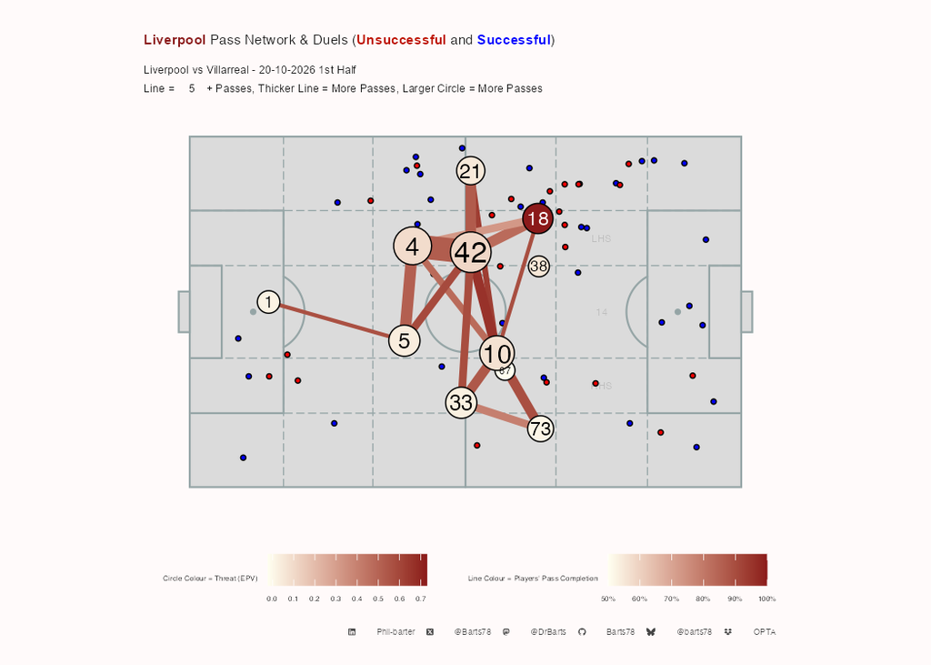

Away Pass Maps

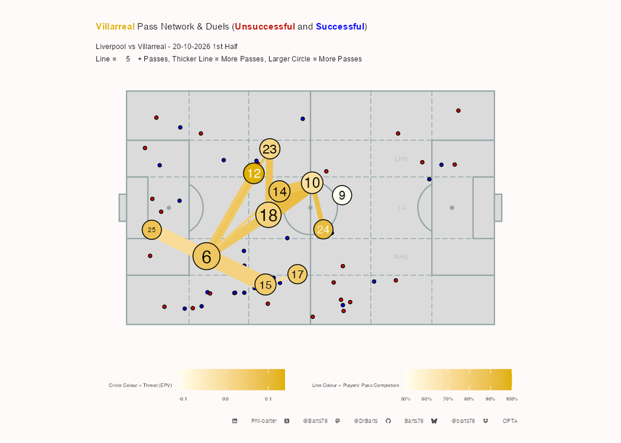

Home Pass Maps by Time

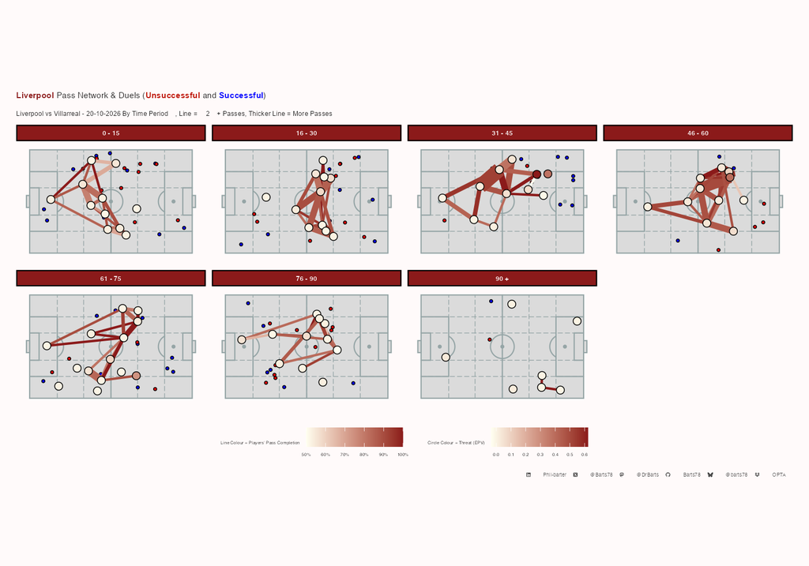

Away Pass Maps by Time

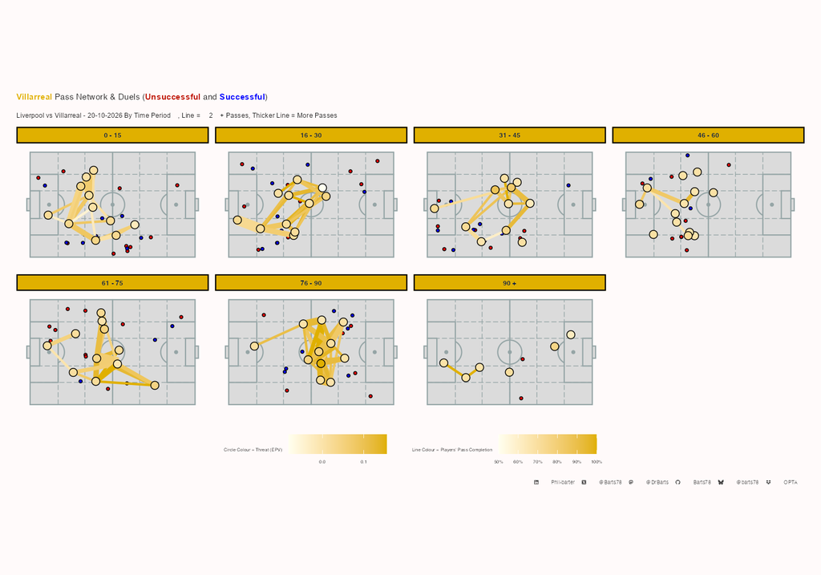

Home Attacking Pass Maps

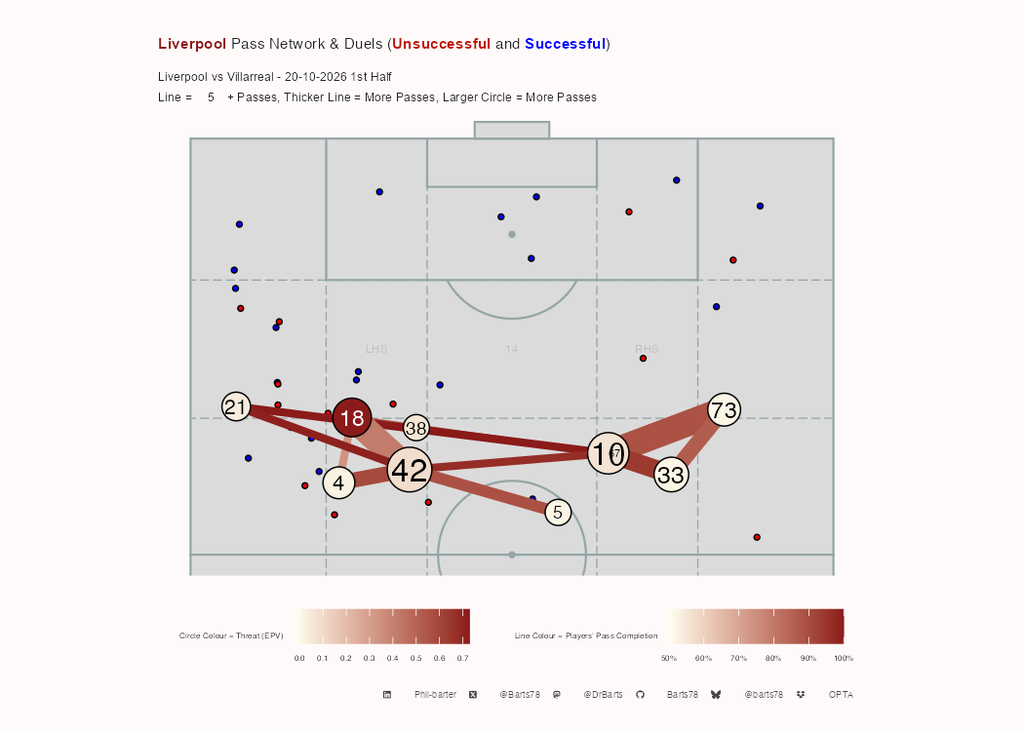

Away Attacking Pass Maps

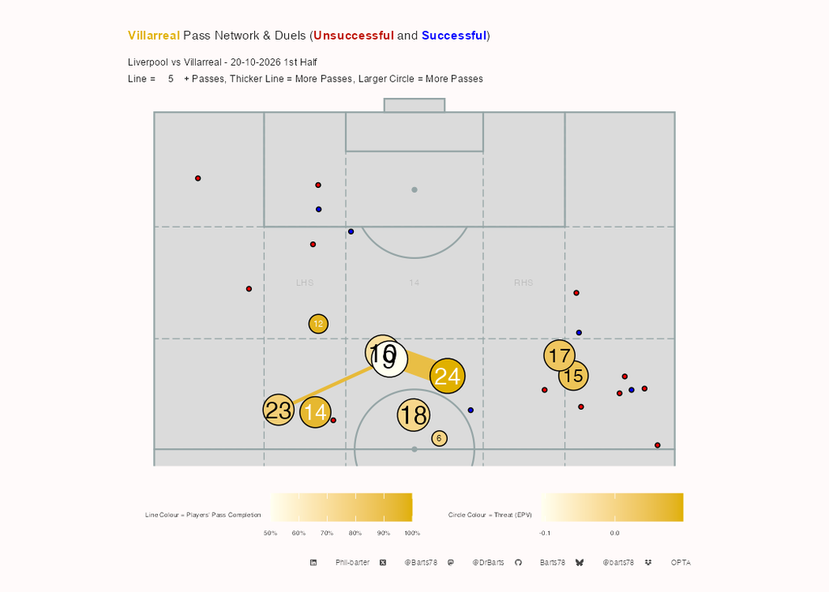

Home Attacking Pass Maps by Time

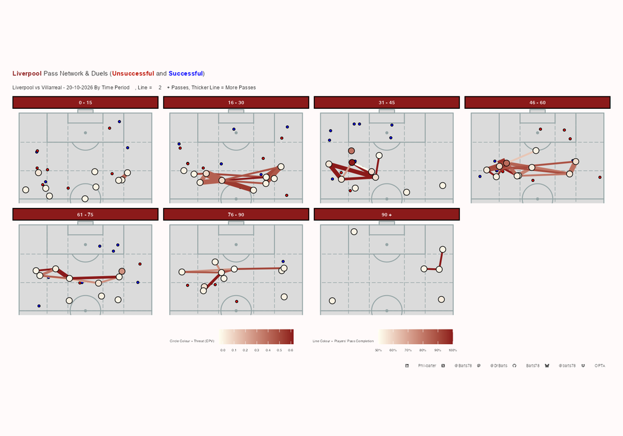

Away Attacking Pass Maps by Time

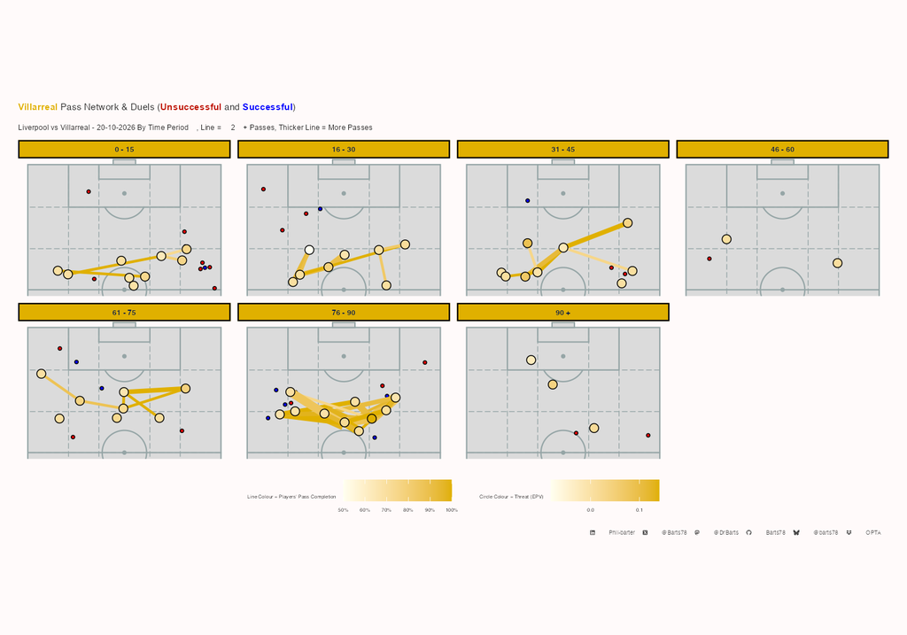

**Pass Connections by Passer**

Liverpool Open Play Passing connections

Liverpool vs Villarreal - 20-10-2026 | Completed passes only, min 5 per pair. Passer Completion % = all of the passer's attempts

|  | Completed Passes | % of Passer's Completions | % of Receiver's Receptions | Passer Completion % | Long Passes | Final Third Passes | PK Box Passes | Crosses | Key Passes | Prog Passes | EPV | EPV / Pass | Pass Time |
| --- | --- | --- | --- | --- | --- | --- | --- | --- | --- | --- | --- | --- | --- |
| Alexis Mac Allister |  |  |  |  |  |  |  |  |  |  |  |  |  |
| Cody Gakpo | 8 | 15% | 15% | 88% | 2 | 3 | 1 | 0 | 1 | 1 | 0.046 | 0.006 | 4.00 |
| Kostas Tsimikas | 5 | 9% | 11% | 88% | 1 | 1 | 0 | 0 | 0 | 0 | 0.016 | 0.003 | 2.80 |
| Rio Ngumoha | 7 | 13% | 26% | 88% | 0 | 2 | 0 | 0 | 0 | 0 | 0.022 | 0.003 | 4.71 |
| Ronald Araujo | 7 | 13% | 32% | 88% | 1 | 1 | 0 | 0 | 0 | 0 | 0.021 | 0.003 | 3.86 |
| Ryan Gravenberch | 6 | 11% | 18% | 88% | 0 | 2 | 0 | 0 | 0 | 0 | 0.007 | 0.001 | 2.17 |
| Trey Nyoni | 5 | 9% | 7% | 88% | 0 | 1 | 0 | 0 | 0 | 0 | 0.010 | 0.002 | 2.20 |
| Alisson Becker |  |  |  |  |  |  |  |  |  |  |  |  |  |
| Jérémy Jacquet | 5 | 25% | 18% | 80% | 0 | 0 | 0 | 0 | 0 | 0 | 0.001 | 0.000 | 3.40 |
| Cody Gakpo |  |  |  |  |  |  |  |  |  |  |  |  |  |
| Florian Wirtz | 13 | 30% | 36% | 80% | 0 | 8 | 0 | 0 | 2 | 2 | 0.118 | 0.009 | 2.15 |
| Kostas Tsimikas | 9 | 20% | 20% | 80% | 0 | 4 | 0 | 0 | 0 | 0 | 0.037 | 0.004 | 2.11 |
| Trey Nyoni | 11 | 25% | 16% | 80% | 0 | 6 | 0 | 0 | 1 | 0 | 0.026 | 0.002 | 1.18 |
| Florian Wirtz |  |  |  |  |  |  |  |  |  |  |  |  |  |
| Cody Gakpo | 7 | 21% | 13% | 90% | 0 | 4 | 0 | 0 | 1 | 0 | 0.015 | 0.002 | 3.86 |
| Kostas Tsimikas | 7 | 21% | 16% | 90% | 0 | 6 | 0 | 0 | 0 | 0 | 0.036 | 0.005 | 2.29 |
| Trey Nyoni | 7 | 21% | 10% | 90% | 0 | 4 | 0 | 0 | 0 | 0 | 0.020 | 0.003 | 2.43 |
| Jérémy Jacquet |  |  |  |  |  |  |  |  |  |  |  |  |  |
| Trey Nyoni | 7 | 19% | 10% | 82% | 0 | 0 | 0 | 0 | 0 | 0 | 0.008 | 0.001 | 2.43 |
| Virgil van Dijk | 10 | 28% | 25% | 82% | 1 | 0 | 0 | 0 | 0 | 0 | 0.005 | 0.000 | 2.90 |
| Kostas Tsimikas |  |  |  |  |  |  |  |  |  |  |  |  |  |
| Alisson Becker | 5 | 12% | 24% | 85% | 1 | 0 | 0 | 0 | 0 | 0 | 0.011 | 0.002 | 2.40 |
| Cody Gakpo | 8 | 20% | 15% | 85% | 0 | 4 | 0 | 0 | 0 | 1 | 0.026 | 0.003 | 2.62 |
| Florian Wirtz | 6 | 15% | 17% | 85% | 0 | 4 | 0 | 0 | 1 | 2 | 0.036 | 0.006 | 2.17 |
| Trey Nyoni | 9 | 22% | 13% | 85% | 0 | 5 | 0 | 0 | 0 | 1 | 0.029 | 0.003 | 2.78 |
| Rio Ngumoha |  |  |  |  |  |  |  |  |  |  |  |  |  |
| Alexis Mac Allister | 9 | 38% | 18% | 86% | 0 | 5 | 1 | 0 | 1 | 1 | 0.298 | 0.033 | 1.67 |
| Ronald Araujo |  |  |  |  |  |  |  |  |  |  |  |  |  |
| Alexis Mac Allister | 5 | 26% | 10% | 76% | 0 | 2 | 0 | 0 | 0 | 0 | 0.004 | 0.001 | 2.80 |
| Rio Ngumoha | 7 | 37% | 26% | 76% | 0 | 0 | 0 | 0 | 0 | 0 | 0.011 | 0.002 | 3.14 |
| Ryan Gravenberch |  |  |  |  |  |  |  |  |  |  |  |  |  |
| Jérémy Jacquet | 7 | 21% | 25% | 94% | 0 | 1 | 0 | 0 | 0 | 0 | 0.011 | 0.002 | 3.00 |
| Rio Ngumoha | 6 | 18% | 22% | 94% | 0 | 3 | 0 | 0 | 0 | 1 | 0.010 | 0.002 | 4.67 |
| Trey Nyoni | 5 | 15% | 7% | 94% | 0 | 1 | 0 | 0 | 0 | 0 | 0.004 | 0.001 | 3.00 |
| Trey Nyoni |  |  |  |  |  |  |  |  |  |  |  |  |  |
| Alexis Mac Allister | 12 | 15% | 24% | 94% | 0 | 3 | 0 | 0 | 1 | 3 | 0.027 | 0.002 | 2.42 |
| Cody Gakpo | 14 | 17% | 26% | 94% | 0 | 6 | 0 | 0 | 0 | 2 | 0.048 | 0.003 | 2.29 |
| Florian Wirtz | 7 | 8% | 19% | 94% | 0 | 0 | 0 | 0 | 0 | 1 | 0.025 | 0.004 | 3.71 |
| Kostas Tsimikas | 8 | 10% | 18% | 94% | 0 | 0 | 0 | 0 | 0 | 0 | 0.024 | 0.003 | 3.00 |
| Ronald Araujo | 7 | 8% | 32% | 94% | 0 | 0 | 0 | 0 | 0 | 0 | 0.013 | 0.002 | 2.57 |
| Ryan Gravenberch | 8 | 10% | 24% | 94% | 0 | 3 | 1 | 0 | 1 | 2 | 0.066 | 0.008 | 3.38 |
| Virgil van Dijk | 13 | 16% | 32% | 94% | 0 | 1 | 0 | 0 | 0 | 0 | 0.011 | 0.001 | 3.31 |
| Virgil van Dijk |  |  |  |  |  |  |  |  |  |  |  |  |  |
| Alexis Mac Allister | 8 | 15% | 16% | 84% | 0 | 0 | 0 | 0 | 0 | 3 | 0.021 | 0.003 | 2.50 |
| Cody Gakpo | 8 | 15% | 15% | 84% | 0 | 0 | 0 | 0 | 0 | 1 | 0.027 | 0.003 | 2.00 |
| Kostas Tsimikas | 7 | 14% | 16% | 84% | 1 | 0 | 0 | 0 | 0 | 0 | 0.021 | 0.003 | 3.29 |
| Trey Nyoni | 14 | 27% | 20% | 84% | 0 | 1 | 0 | 0 | 0 | 0 | 0.017 | 0.001 | 2.93 |

X @Barts78 · Bluesky @barts78 · Mastodon @DrBarts · GitHub Barts78 · LinkedIn Phil-barter · Data: Opta

**Pass Connections by Receiver**

Liverpool Open Play Passing connections

Liverpool vs Villarreal - 20-10-2026 | Completed passes only, min 5 per pair. Passer Completion % = all of the passer's attempts

|  | Completed Passes | % of Passer's Completions | % of Receiver's Receptions | Passer Completion % | Long Passes | Final Third Passes | PK Box Passes | Crosses | Key Passes | Prog Passes | EPV | EPV / Pass | Pass Time |
| --- | --- | --- | --- | --- | --- | --- | --- | --- | --- | --- | --- | --- | --- |
| Cody Gakpo |  |  |  |  |  |  |  |  |  |  |  |  |  |
| Alexis Mac Allister | 8 | 15% | 15% | 88% | 2 | 3 | 1 | 0 | 1 | 1 | 0.046 | 0.006 | 4.00 |
| Florian Wirtz | 7 | 21% | 13% | 90% | 0 | 4 | 0 | 0 | 1 | 0 | 0.015 | 0.002 | 3.86 |
| Kostas Tsimikas | 8 | 20% | 15% | 85% | 0 | 4 | 0 | 0 | 0 | 1 | 0.026 | 0.003 | 2.62 |
| Trey Nyoni | 14 | 17% | 26% | 94% | 0 | 6 | 0 | 0 | 0 | 2 | 0.048 | 0.003 | 2.29 |
| Virgil van Dijk | 8 | 15% | 15% | 84% | 0 | 0 | 0 | 0 | 0 | 1 | 0.027 | 0.003 | 2.00 |
| Kostas Tsimikas |  |  |  |  |  |  |  |  |  |  |  |  |  |
| Alexis Mac Allister | 5 | 9% | 11% | 88% | 1 | 1 | 0 | 0 | 0 | 0 | 0.016 | 0.003 | 2.80 |
| Cody Gakpo | 9 | 20% | 20% | 80% | 0 | 4 | 0 | 0 | 0 | 0 | 0.037 | 0.004 | 2.11 |
| Florian Wirtz | 7 | 21% | 16% | 90% | 0 | 6 | 0 | 0 | 0 | 0 | 0.036 | 0.005 | 2.29 |
| Trey Nyoni | 8 | 10% | 18% | 94% | 0 | 0 | 0 | 0 | 0 | 0 | 0.024 | 0.003 | 3.00 |
| Virgil van Dijk | 7 | 14% | 16% | 84% | 1 | 0 | 0 | 0 | 0 | 0 | 0.021 | 0.003 | 3.29 |
| Rio Ngumoha |  |  |  |  |  |  |  |  |  |  |  |  |  |
| Alexis Mac Allister | 7 | 13% | 26% | 88% | 0 | 2 | 0 | 0 | 0 | 0 | 0.022 | 0.003 | 4.71 |
| Ronald Araujo | 7 | 37% | 26% | 76% | 0 | 0 | 0 | 0 | 0 | 0 | 0.011 | 0.002 | 3.14 |
| Ryan Gravenberch | 6 | 18% | 22% | 94% | 0 | 3 | 0 | 0 | 0 | 1 | 0.010 | 0.002 | 4.67 |
| Ronald Araujo |  |  |  |  |  |  |  |  |  |  |  |  |  |
| Alexis Mac Allister | 7 | 13% | 32% | 88% | 1 | 1 | 0 | 0 | 0 | 0 | 0.021 | 0.003 | 3.86 |
| Trey Nyoni | 7 | 8% | 32% | 94% | 0 | 0 | 0 | 0 | 0 | 0 | 0.013 | 0.002 | 2.57 |
| Ryan Gravenberch |  |  |  |  |  |  |  |  |  |  |  |  |  |
| Alexis Mac Allister | 6 | 11% | 18% | 88% | 0 | 2 | 0 | 0 | 0 | 0 | 0.007 | 0.001 | 2.17 |
| Trey Nyoni | 8 | 10% | 24% | 94% | 0 | 3 | 1 | 0 | 1 | 2 | 0.066 | 0.008 | 3.38 |
| Trey Nyoni |  |  |  |  |  |  |  |  |  |  |  |  |  |
| Alexis Mac Allister | 5 | 9% | 7% | 88% | 0 | 1 | 0 | 0 | 0 | 0 | 0.010 | 0.002 | 2.20 |
| Cody Gakpo | 11 | 25% | 16% | 80% | 0 | 6 | 0 | 0 | 1 | 0 | 0.026 | 0.002 | 1.18 |
| Florian Wirtz | 7 | 21% | 10% | 90% | 0 | 4 | 0 | 0 | 0 | 0 | 0.020 | 0.003 | 2.43 |
| Jérémy Jacquet | 7 | 19% | 10% | 82% | 0 | 0 | 0 | 0 | 0 | 0 | 0.008 | 0.001 | 2.43 |
| Kostas Tsimikas | 9 | 22% | 13% | 85% | 0 | 5 | 0 | 0 | 0 | 1 | 0.029 | 0.003 | 2.78 |
| Ryan Gravenberch | 5 | 15% | 7% | 94% | 0 | 1 | 0 | 0 | 0 | 0 | 0.004 | 0.001 | 3.00 |
| Virgil van Dijk | 14 | 27% | 20% | 84% | 0 | 1 | 0 | 0 | 0 | 0 | 0.017 | 0.001 | 2.93 |
| Jérémy Jacquet |  |  |  |  |  |  |  |  |  |  |  |  |  |
| Alisson Becker | 5 | 25% | 18% | 80% | 0 | 0 | 0 | 0 | 0 | 0 | 0.001 | 0.000 | 3.40 |
| Ryan Gravenberch | 7 | 21% | 25% | 94% | 0 | 1 | 0 | 0 | 0 | 0 | 0.011 | 0.002 | 3.00 |
| Florian Wirtz |  |  |  |  |  |  |  |  |  |  |  |  |  |
| Cody Gakpo | 13 | 30% | 36% | 80% | 0 | 8 | 0 | 0 | 2 | 2 | 0.118 | 0.009 | 2.15 |
| Kostas Tsimikas | 6 | 15% | 17% | 85% | 0 | 4 | 0 | 0 | 1 | 2 | 0.036 | 0.006 | 2.17 |
| Trey Nyoni | 7 | 8% | 19% | 94% | 0 | 0 | 0 | 0 | 0 | 1 | 0.025 | 0.004 | 3.71 |
| Virgil van Dijk |  |  |  |  |  |  |  |  |  |  |  |  |  |
| Jérémy Jacquet | 10 | 28% | 25% | 82% | 1 | 0 | 0 | 0 | 0 | 0 | 0.005 | 0.000 | 2.90 |
| Trey Nyoni | 13 | 16% | 32% | 94% | 0 | 1 | 0 | 0 | 0 | 0 | 0.011 | 0.001 | 3.31 |
| Alisson Becker |  |  |  |  |  |  |  |  |  |  |  |  |  |
| Kostas Tsimikas | 5 | 12% | 24% | 85% | 1 | 0 | 0 | 0 | 0 | 0 | 0.011 | 0.002 | 2.40 |
| Alexis Mac Allister |  |  |  |  |  |  |  |  |  |  |  |  |  |
| Rio Ngumoha | 9 | 38% | 18% | 86% | 0 | 5 | 1 | 0 | 1 | 1 | 0.298 | 0.033 | 1.67 |
| Ronald Araujo | 5 | 26% | 10% | 76% | 0 | 2 | 0 | 0 | 0 | 0 | 0.004 | 0.001 | 2.80 |
| Trey Nyoni | 12 | 15% | 24% | 94% | 0 | 3 | 0 | 0 | 1 | 3 | 0.027 | 0.002 | 2.42 |
| Virgil van Dijk | 8 | 15% | 16% | 84% | 0 | 0 | 0 | 0 | 0 | 3 | 0.021 | 0.003 | 2.50 |

X @Barts78 · Bluesky @barts78 · Mastodon @DrBarts · GitHub Barts78 · LinkedIn Phil-barter · Data: Opta

**Away Pass Connections by Passer**

Villarreal Open Play Passing connections

Liverpool vs Villarreal - 20-10-2026 | Completed passes only, min 5 per pair. Passer Completion % = all of the passer's attempts

|  | Completed Passes | % of Passer's Completions | % of Receiver's Receptions | Passer Completion % | Long Passes | Final Third Passes | PK Box Passes | Crosses | Key Passes | Prog Passes | EPV | EPV / Pass | Pass Time |
| --- | --- | --- | --- | --- | --- | --- | --- | --- | --- | --- | --- | --- | --- |
| Alberto Moleiro |  |  |  |  |  |  |  |  |  |  |  |  |  |
| Pape Gueye | 6 | 27% | 11% | 96% | 0 | 0 | 0 | 0 | 0 | 0 | 0.004 | 0.001 | 2.33 |
| Santi Comesaña | 5 | 23% | 17% | 96% | 0 | 0 | 0 | 0 | 0 | 1 | 0.010 | 0.002 | 1.80 |
| Alex Freeman |  |  |  |  |  |  |  |  |  |  |  |  |  |
| Santiago Mouriño | 7 | 37% | 21% | 95% | 0 | 3 | 0 | 0 | 0 | 0 | 0.018 | 0.003 | 2.86 |
| Juan Foyth |  |  |  |  |  |  |  |  |  |  |  |  |  |
| Gerard Moreno | 5 | 13% | 25% | 93% | 0 | 1 | 0 | 0 | 0 | 1 | 0.009 | 0.002 | 2.80 |
| Pape Gueye | 9 | 23% | 17% | 93% | 1 | 1 | 0 | 0 | 0 | 1 | 0.028 | 0.003 | 2.67 |
| Tani Oluwaseyi | 7 | 18% | 41% | 93% | 2 | 1 | 0 | 0 | 0 | 1 | 0.039 | 0.006 | 3.14 |
| Pape Gueye |  |  |  |  |  |  |  |  |  |  |  |  |  |
| Pau Navarro | 10 | 19% | 22% | 86% | 0 | 0 | 0 | 0 | 0 | 0 | 0.027 | 0.003 | 2.50 |
| Sergi Cardona | 9 | 17% | 29% | 86% | 2 | 3 | 0 | 0 | 0 | 0 | 0.025 | 0.003 | 2.44 |
| Pau Navarro |  |  |  |  |  |  |  |  |  |  |  |  |  |
| Juan Foyth | 5 | 10% | 12% | 83% | 0 | 0 | 0 | 0 | 0 | 0 | 0.008 | 0.002 | 1.60 |
| Pape Gueye | 7 | 14% | 13% | 83% | 0 | 0 | 0 | 0 | 0 | 0 | 0.010 | 0.001 | 2.71 |
| Péter Gulácsi | 7 | 14% | 35% | 83% | 0 | 0 | 0 | 0 | 0 | 0 | 0.005 | 0.001 | 3.57 |
| Santiago Mouriño | 9 | 18% | 26% | 83% | 0 | 0 | 0 | 0 | 0 | 0 | 0.004 | 0.000 | 2.22 |
| Péter Gulácsi |  |  |  |  |  |  |  |  |  |  |  |  |  |
| Pau Navarro | 10 | 50% | 22% | 67% | 0 | 0 | 0 | 0 | 0 | 0 | 0.009 | 0.001 | 2.20 |
| Renato Veiga |  |  |  |  |  |  |  |  |  |  |  |  |  |
| Pape Gueye | 7 | 21% | 13% | 85% | 1 | 1 | 0 | 0 | 0 | 0 | 0.014 | 0.002 | 1.86 |
| Pau Navarro | 7 | 21% | 15% | 85% | 0 | 0 | 0 | 0 | 0 | 0 | 0.004 | 0.001 | 2.43 |
| Péter Gulácsi | 7 | 21% | 35% | 85% | 0 | 0 | 0 | 0 | 0 | 0 | 0.009 | 0.001 | 2.86 |
| Santi Comesaña |  |  |  |  |  |  |  |  |  |  |  |  |  |
| Alberto Moleiro | 6 | 19% | 26% | 80% | 0 | 0 | 0 | 0 | 1 | 0 | 0.009 | 0.002 | 3.83 |
| Juan Foyth | 5 | 16% | 12% | 80% | 0 | 1 | 0 | 0 | 0 | 0 | 0.007 | 0.001 | 2.20 |
| Pau Navarro | 5 | 16% | 11% | 80% | 0 | 0 | 0 | 0 | 0 | 0 | 0.008 | 0.002 | 1.00 |
| Santiago Mouriño |  |  |  |  |  |  |  |  |  |  |  |  |  |
| Juan Foyth | 5 | 15% | 12% | 75% | 0 | 0 | 0 | 0 | 0 | 0 | 0.005 | 0.001 | 1.00 |
| Santi Comesaña | 5 | 15% | 17% | 75% | 0 | 0 | 0 | 0 | 0 | 0 | 0.011 | 0.002 | 1.60 |
| Sergi Cardona |  |  |  |  |  |  |  |  |  |  |  |  |  |
| Pape Gueye | 8 | 24% | 15% | 89% | 0 | 3 | 0 | 0 | 0 | 1 | 0.022 | 0.003 | 2.50 |
| Pau Navarro | 5 | 15% | 11% | 89% | 0 | 0 | 0 | 0 | 0 | 0 | 0.007 | 0.001 | 3.00 |
| Tajon Buchanan |  |  |  |  |  |  |  |  |  |  |  |  |  |
| Santiago Mouriño | 5 | 36% | 15% | 78% | 0 | 0 | 0 | 0 | 1 | 2 | 0.024 | 0.005 | 3.40 |

X @Barts78 · Bluesky @barts78 · Mastodon @DrBarts · GitHub Barts78 · LinkedIn Phil-barter · Data: Opta

**Away Pass Connections by Receiver**

Villarreal Open Play Passing connections

Liverpool vs Villarreal - 20-10-2026 | Completed passes only, min 5 per pair. Passer Completion % = all of the passer's attempts

|  | Completed Passes | % of Passer's Completions | % of Receiver's Receptions | Passer Completion % | Long Passes | Final Third Passes | PK Box Passes | Crosses | Key Passes | Prog Passes | EPV | EPV / Pass | Pass Time |
| --- | --- | --- | --- | --- | --- | --- | --- | --- | --- | --- | --- | --- | --- |
| Pape Gueye |  |  |  |  |  |  |  |  |  |  |  |  |  |
| Alberto Moleiro | 6 | 27% | 11% | 96% | 0 | 0 | 0 | 0 | 0 | 0 | 0.004 | 0.001 | 2.33 |
| Juan Foyth | 9 | 23% | 17% | 93% | 1 | 1 | 0 | 0 | 0 | 1 | 0.028 | 0.003 | 2.67 |
| Pau Navarro | 7 | 14% | 13% | 83% | 0 | 0 | 0 | 0 | 0 | 0 | 0.010 | 0.001 | 2.71 |
| Renato Veiga | 7 | 21% | 13% | 85% | 1 | 1 | 0 | 0 | 0 | 0 | 0.014 | 0.002 | 1.86 |
| Sergi Cardona | 8 | 24% | 15% | 89% | 0 | 3 | 0 | 0 | 0 | 1 | 0.022 | 0.003 | 2.50 |
| Santi Comesaña |  |  |  |  |  |  |  |  |  |  |  |  |  |
| Alberto Moleiro | 5 | 23% | 17% | 96% | 0 | 0 | 0 | 0 | 0 | 1 | 0.010 | 0.002 | 1.80 |
| Santiago Mouriño | 5 | 15% | 17% | 75% | 0 | 0 | 0 | 0 | 0 | 0 | 0.011 | 0.002 | 1.60 |
| Santiago Mouriño |  |  |  |  |  |  |  |  |  |  |  |  |  |
| Alex Freeman | 7 | 37% | 21% | 95% | 0 | 3 | 0 | 0 | 0 | 0 | 0.018 | 0.003 | 2.86 |
| Pau Navarro | 9 | 18% | 26% | 83% | 0 | 0 | 0 | 0 | 0 | 0 | 0.004 | 0.000 | 2.22 |
| Tajon Buchanan | 5 | 36% | 15% | 78% | 0 | 0 | 0 | 0 | 1 | 2 | 0.024 | 0.005 | 3.40 |
| Gerard Moreno |  |  |  |  |  |  |  |  |  |  |  |  |  |
| Juan Foyth | 5 | 13% | 25% | 93% | 0 | 1 | 0 | 0 | 0 | 1 | 0.009 | 0.002 | 2.80 |
| Tani Oluwaseyi |  |  |  |  |  |  |  |  |  |  |  |  |  |
| Juan Foyth | 7 | 18% | 41% | 93% | 2 | 1 | 0 | 0 | 0 | 1 | 0.039 | 0.006 | 3.14 |
| Pau Navarro |  |  |  |  |  |  |  |  |  |  |  |  |  |
| Pape Gueye | 10 | 19% | 22% | 86% | 0 | 0 | 0 | 0 | 0 | 0 | 0.027 | 0.003 | 2.50 |
| Péter Gulácsi | 10 | 50% | 22% | 67% | 0 | 0 | 0 | 0 | 0 | 0 | 0.009 | 0.001 | 2.20 |
| Renato Veiga | 7 | 21% | 15% | 85% | 0 | 0 | 0 | 0 | 0 | 0 | 0.004 | 0.001 | 2.43 |
| Santi Comesaña | 5 | 16% | 11% | 80% | 0 | 0 | 0 | 0 | 0 | 0 | 0.008 | 0.002 | 1.00 |
| Sergi Cardona | 5 | 15% | 11% | 89% | 0 | 0 | 0 | 0 | 0 | 0 | 0.007 | 0.001 | 3.00 |
| Sergi Cardona |  |  |  |  |  |  |  |  |  |  |  |  |  |
| Pape Gueye | 9 | 17% | 29% | 86% | 2 | 3 | 0 | 0 | 0 | 0 | 0.025 | 0.003 | 2.44 |
| Juan Foyth |  |  |  |  |  |  |  |  |  |  |  |  |  |
| Pau Navarro | 5 | 10% | 12% | 83% | 0 | 0 | 0 | 0 | 0 | 0 | 0.008 | 0.002 | 1.60 |
| Santi Comesaña | 5 | 16% | 12% | 80% | 0 | 1 | 0 | 0 | 0 | 0 | 0.007 | 0.001 | 2.20 |
| Santiago Mouriño | 5 | 15% | 12% | 75% | 0 | 0 | 0 | 0 | 0 | 0 | 0.005 | 0.001 | 1.00 |
| Péter Gulácsi |  |  |  |  |  |  |  |  |  |  |  |  |  |
| Pau Navarro | 7 | 14% | 35% | 83% | 0 | 0 | 0 | 0 | 0 | 0 | 0.005 | 0.001 | 3.57 |
| Renato Veiga | 7 | 21% | 35% | 85% | 0 | 0 | 0 | 0 | 0 | 0 | 0.009 | 0.001 | 2.86 |
| Alberto Moleiro |  |  |  |  |  |  |  |  |  |  |  |  |  |
| Santi Comesaña | 6 | 19% | 26% | 80% | 0 | 0 | 0 | 0 | 1 | 0 | 0.009 | 0.002 | 3.83 |

X @Barts78 · Bluesky @barts78 · Mastodon @DrBarts · GitHub Barts78 · LinkedIn Phil-barter · Data: Opta

Home Passing Tree Plot

[figure not shown]

Away Passing Tree Plot

[figure not shown]

Home wave plot

[figure not shown]

Away wave plot

[figure not shown]

**Home 1st Half Pass receiving Areas**

[figure not shown]

**Home 2nd Half Pass receiving Areas**

[figure not shown]

**Home Up to 1st Sub Pass receiving Areas**

[figure not shown]

**Away 1st Half Pass receiving Areas**

[figure not shown]

**Away 2nd Half Pass receiving Areas**

[figure not shown]

**Away Up to 1st Sub Pass receiving Areas**

[figure not shown]

Home Passing chains

[figure not shown]

Away Passing Chains

[figure not shown]

**Full time**

Liverpool FT Passing Chain Length (5, 6-10, 11-15, 16 +) & Distance (m)

Liverpool vs Villarreal - 20-10-2026

|  | Pass Chain Length | Total Chain Passes | Max Chain Length | Average Chain Length | Percent of Teams Passes | Total Chain Distance | Max Chain Distance | Average Chain Distance | Percent of Teams Passing Distance |
| --- | --- | --- | --- | --- | --- | --- | --- | --- | --- |
|  | VLow | 199 | 5 | 3 | 41% | 2,581.84 | 134.24 | 13.00 | 40% |
|  | Low | 177 | 10 | 8 | 37% | 2,488.08 | 179.77 | 14.10 | 38% |
|  | Medium | 71 | 14 | 12 | 15% | 1,026.89 | 255.42 | 14.50 | 16% |
|  | High | 36 | 20 | 18 | 7% | 406.34 | 220.28 | 11.30 | 6% |
| Overall Totals | — | 483 | 49 | 41 | — | 6,503 | 790 | 53 | — |
| Overall Average | — | 121 | 12 | 10 | — | 1,626 | 197 | 13 | — |

X @Barts78 · Bluesky @barts78 · Mastodon @DrBarts · GitHub Barts78 · LinkedIn Phil-barter · Data: Opta

**1st Half**

Liverpool 1st Half Passing Chain Length (5, 6-10, 11-15, 16 +) & Distance (m)

Liverpool vs Villarreal - 20-10-2026

|  | Pass Chain Length | Total Chain Passes | Max Chain Length | Average Chain Length | Percent of Teams Passes | Total Chain Distance | Max Chain Distance | Average Chain Distance | Percent of Teams Passing Distance |
| --- | --- | --- | --- | --- | --- | --- | --- | --- | --- |
|  | VLow | 93 | 5 | 3 | 40% | 1,117.55 | 134.24 | 12.00 | 38% |
|  | Low | 94 | 10 | 9 | 41% | 1,371.49 | 179.77 | 14.60 | 46% |
|  | Medium | 23 | 12 | 12 | 10% | 241.57 | 156.46 | 10.50 | 8% |
|  | High | 20 | 20 | 20 | 9% | 220.28 | 220.28 | 11.00 | 7% |
| Overall Totals | — | 230 | 47 | 44 | — | 2,951 | 691 | 48 | — |
| Overall Average | — | 58 | 12 | 11 | — | 738 | 173 | 12 | — |

X @Barts78 · Bluesky @barts78 · Mastodon @DrBarts · GitHub Barts78 · LinkedIn Phil-barter · Data: Opta

**2nd Half**

Liverpool 2nd Half Passing Chain Length (5, 6-10, 11-15, 16 +) & Distance (m)

Liverpool vs Villarreal - 20-10-2026

|  | Pass Chain Length | Total Chain Passes | Max Chain Length | Average Chain Length | Percent of Teams Passes | Total Chain Distance | Max Chain Distance | Average Chain Distance | Percent of Teams Passing Distance |
| --- | --- | --- | --- | --- | --- | --- | --- | --- | --- |
|  | VLow | 106 | 5 | 3 | 42% | 1,464.29 | 102.45 | 13.80 | 41% |
|  | Low | 83 | 10 | 8 | 33% | 1,116.59 | 149.33 | 13.50 | 31% |
|  | Medium | 48 | 14 | 12 | 19% | 785.32 | 255.42 | 16.40 | 22% |
|  | High | 16 | 16 | 16 | 6% | 186.06 | 186.06 | 11.60 | 5% |
| Overall Totals | — | 253 | 45 | 39 | — | 3,552 | 693 | 55 | — |
| Overall Average | — | 63 | 11 | 10 | — | 888 | 173 | 14 | — |

X @Barts78 · Bluesky @barts78 · Mastodon @DrBarts · GitHub Barts78 · LinkedIn Phil-barter · Data: Opta

**Away Full time**

Villarreal FT Passing Chain Length (5, 6-10, 11-15, 16 +) & Distance (m)

Liverpool vs Villarreal - 20-10-2026

|  | Pass Chain Length | Total Chain Passes | Max Chain Length | Average Chain Length | Percent of Teams Passes | Total Chain Distance | Max Chain Distance | Average Chain Distance | Percent of Teams Passing Distance |
| --- | --- | --- | --- | --- | --- | --- | --- | --- | --- |
|  | VLow | 218 | 5 | 3 | 50% | 2,773.38 | 124.02 | 12.70 | 50% |
|  | Low | 132 | 10 | 8 | 30% | 1,680.83 | 181.99 | 12.70 | 30% |
|  | Medium | 50 | 14 | 13 | 11% | 662.53 | 183.51 | 13.30 | 12% |
|  | High | 37 | 19 | 19 | 8% | 479.93 | 256.02 | 13.00 | 9% |
| Overall Totals | — | 437 | 48 | 43 | — | 5,597 | 746 | 52 | — |
| Overall Average | — | 109 | 12 | 11 | — | 1,399 | 186 | 13 | — |

X @Barts78 · Bluesky @barts78 · Mastodon @DrBarts · GitHub Barts78 · LinkedIn Phil-barter · Data: Opta

**Away 1st Half**

Villarreal 1st Half Passing Chain Length (5, 6-10, 11-15, 16 +) & Distance (m)

Liverpool vs Villarreal - 20-10-2026

|  | Pass Chain Length | Total Chain Passes | Max Chain Length | Average Chain Length | Percent of Teams Passes | Total Chain Distance | Max Chain Distance | Average Chain Distance | Percent of Teams Passing Distance |
| --- | --- | --- | --- | --- | --- | --- | --- | --- | --- |
|  | VLow | 115 | 5 | 3 | 61% | 1,555.42 | 90.03 | 13.50 | 62% |
|  | Low | 24 | 9 | 8 | 13% | 323.05 | 142.10 | 13.50 | 13% |
|  | Medium | 11 | 11 | 11 | 6% | 161.32 | 161.32 | 14.70 | 6% |
|  | High | 37 | 19 | 19 | 20% | 479.93 | 256.02 | 13.00 | 19% |
| Overall Totals | — | 187 | 44 | 41 | — | 2,520 | 649 | 55 | — |
| Overall Average | — | 47 | 11 | 10 | — | 630 | 162 | 14 | — |

X @Barts78 · Bluesky @barts78 · Mastodon @DrBarts · GitHub Barts78 · LinkedIn Phil-barter · Data: Opta

**Away 2nd Half**

Villarreal 2nd Half Passing Chain Length (5, 6-10, 11-15, 16 +) & Distance (m)

Liverpool vs Villarreal - 20-10-2026

|  | Pass Chain Length | Total Chain Passes | Max Chain Length | Average Chain Length | Percent of Teams Passes | Total Chain Distance | Max Chain Distance | Average Chain Distance | Percent of Teams Passing Distance |
| --- | --- | --- | --- | --- | --- | --- | --- | --- | --- |
|  | VLow | 103 | 5 | 3 | 41% | 1,217.96 | 124.02 | 11.80 | 40% |
|  | Low | 108 | 10 | 8 | 43% | 1,357.78 | 181.99 | 12.60 | 44% |
|  | Medium | 39 | 14 | 13 | 16% | 501.21 | 183.51 | 12.90 | 16% |
| Overall Totals | — | 250 | 29 | 24 | — | 3,077 | 490 | 37 | — |
| Overall Average | — | 83 | 10 | 8 | — | 1,026 | 163 | 12 | — |

X @Barts78 · Bluesky @barts78 · Mastodon @DrBarts · GitHub Barts78 · LinkedIn Phil-barter · Data: Opta

**Home Z14 RS By Half**

[figure not shown]

**Home Z14 RS By Game Period**

[figure not shown]

**Away Z14 RS By Half**

[figure not shown]

**Away Z14 RS By Game Period**

[figure not shown]

**Home Long Passes By half**

[figure not shown]

**Home Long Passes By Game Period**

[figure not shown]

**Away Long Passes By Half**

[figure not shown]

**Away Long Passes By Game period**

[figure not shown]

Set-Piece Summary

**Set Pieces**

Liverpool vs Villarreal - 20-10-2026

|  | Liverpool | Villarreal |
| --- | --- | --- |
| Corners |  |  |
| Corners taken | 7 | 2 |
| Short | 0 | 1 |
| Direct | 7 | 1 |
| Direct - first contact won | 2 (29%) | 0 (0%) |
| Free kicks |  |  |
| Free kicks (passes) | 13 | 14 |
| Into final third / box | 4 | 1 |
| Into box | 1 | 0 |
| Throw-ins |  |  |
| Throw-ins | 15 | 14 |
| Retained (first touch) | 73% | 86% |
| Shots by situation |  |  |
| Open-play shots | 17 | 14 |
| Open-play xG | 1.73 | 1.58 |
| Open-play goals | 2 | 3 |
| Set-piece shots | 5 | 0 |
| Set-piece xG | 0.66 | 0.00 |
| Set-piece goals | 2 | 0 |
| Penalties | 0 | 0 |
| Penalty xG | 0.00 | 0.00 |
| Set-piece share of xG | 28% | 0% |

First contact: the team that touches the ball first after the delivery (aerial duels go to the winner). Throw-ins retained = first touch by the taking team.  
X @Barts78 · Bluesky @barts78 · Mastodon @DrBarts · GitHub Barts78 · LinkedIn Phil-barter · Data: Opta

**Corners**

[figure not shown]

**Free Kicks**

[figure not shown]

**Corners**

[figure not shown]

**Free Kicks**

[figure not shown]

**Sequence Map**

[figure not shown]

**Sequence Table**

**Liverpool - Shot-Creating Sequences**

Liverpool vs Villarreal - 20-10-2026

| Min | Shooter | Result | xG | Situation | Started by | Started from | Start zone | Passes | Duration (s) |
| --- | --- | --- | --- | --- | --- | --- | --- | --- | --- |
| 8' | Ngumoha | Blocked | 0.07 | Open play | Tsimikas | Open-play regain | Mid third, Left wing | 11 | 37 |
| 22' | van Dijk | Off target | 0.05 | Set piece | Tsimikas | Corner | Att third, Right wing | 1 | 3 |
| 23' | Gravenberch | Saved | 0.05 | Open play | Nyoni | Open-play regain | Att third, Left half-space | 1 | 5 |
| 36' | Mac Allister | Goal | 0.10 | Set piece | Tsimikas | Corner | Att third, Right wing | 1 | 2 |
| 39' | Mac Allister | Off target | 0.02 | Open play | van Dijk | Open-play regain | Mid third, Central | 4 | 19 |
| 42' | Mac Allister | Off target | 0.05 | Set piece | van Dijk | Goal kick | Def third, Central | 4 | 82 |
| 44' | Gakpo | Blocked | 0.06 | Open play | Tsimikas | Throw-in | Mid third, Left wing | 9 | 26 |
| 45+2' | Araujo | Goal | 0.43 | Set piece | Ngumoha | Open-play regain | Att third, Left half-space | 1 | 3 |
| 48' | Gravenberch | Off target | 0.05 | Open play | Gakpo | Open-play regain | Mid third, Left wing | 8 | 24 |
| 48' | Tsimikas | Off target | 0.03 | Set piece | Ngumoha | Open-play regain | Att third, Right half-space | 1 | 6 |
| 53' | Gakpo | Saved | 0.05 | Open play | Jacquet | Open-play regain | Mid third, Right wing | 9 | 28 |
| 57' | Wirtz | Saved | 0.08 | Open play | Jacquet | Open-play regain | Mid third, Left half-space | 9 | 28 |
| 57' | Wirtz | Blocked | 0.02 | Open play | Jacquet | Throw-in | Mid third, Right wing | 5 | 14 |
| 58' | Mac Allister | Blocked | 0.02 | Open play | Mac Allister | Open-play regain | Att third, Right half-space | 0 | 0 |
| 61' | Nyoni | Off target | 0.02 | Open play | Wirtz | Open-play regain | Mid third, Left half-space | 16 | 40 |
| 64' | Wirtz | Blocked | 0.01 | Open play | van Dijk | Open-play regain | Att third, Right half-space | 0 | 2 |
| 65' | Mac Allister | Goal | 0.88 | Open play | Tsimikas | Open-play regain | Def third, Left wing | 13 | 54 |
| 68' | Wirtz | Goal | 0.19 | Open play | Tsimikas | Open-play regain | Mid third, Left wing | 2 | 6 |
| 71' | Ngumoha | Off target | 0.03 | Open play | Wirtz | Open-play regain | Att third, Left half-space | 2 | 12 |
| 72' | Gakpo | Blocked | 0.08 | Open play | Gravenberch | Open-play regain | Def third, Right wing | 8 | 30 |
| 75' | Isak | Off target | 0.05 | Open play | Wirtz | Open-play regain | Att third, Left half-space | 1 | 3 |
| 90' | Isak | Blocked | 0.05 | Open play | Mac Allister | Open-play regain | Mid third, Left half-space | 1 | 5 |

X @Barts78 · Bluesky @barts78 · Mastodon @DrBarts · GitHub Barts78 · LinkedIn Phil-barter · Data: Opta

**Sequence Map**

[figure not shown]

**Sequence Table**

**Villarreal - Shot-Creating Sequences**

Liverpool vs Villarreal - 20-10-2026

| Min | Shooter | Result | xG | Situation | Started by | Started from | Start zone | Passes | Duration (s) |
| --- | --- | --- | --- | --- | --- | --- | --- | --- | --- |
| 4' | Mikautadze | Goal | 0.24 | Open play | Mikautadze | Open-play regain | Att third, Left half-space | 0 | 0 |
| 15' | Saliba | Blocked | 0.05 | Open play | Cardona | Throw-in | Mid third, Left wing | 6 | 13 |
| 22' | Buchanan | Blocked | 0.04 | Open play | Comesaña | Open-play regain | Def third, Right half-space | 5 | 23 |
| 27' | Cardona | Blocked | 0.04 | Open play | Saliba | Open-play regain | Mid third, Central | 18 | 54 |
| 27' | Saliba | Blocked | 0.03 | Open play | Saliba | Open-play regain | Mid third, Central | 18 | 56 |
| 29' | Cardona | Goal | 0.66 | Open play | Gueye | Open-play regain | Def third, Right half-space | 3 | 12 |
| 32' | Moleiro | Off target | 0.03 | Open play | Veiga | Open-play regain | Def third, Central | 19 | 57 |
| 40' | Mouriño | Saved | 0.04 | Open play | Navarro | Free kick | Def third, Right half-space | 11 | 32 |
| 61' | Oluwaseyi | Blocked | 0.03 | Open play | Gulácsi | Goal kick | Def third, Central | 5 | 12 |
| 72' | Gueye | Saved | 0.05 | Open play | Mouriño | Open-play regain | Def third, Right half-space | 12 | 35 |
| 73' | Pérez | Blocked | 0.04 | Open play | Mouriño | Open-play regain | Mid third, Right half-space | 7 | 17 |
| 85' | Moreno | Off target | 0.05 | Open play | Cardona | Throw-in | Def third, Left wing | 9 | 34 |
| 87' | Oluwaseyi | Goal | 0.23 | Open play | Navarro | Open-play regain | Mid third, Central | 4 | 12 |
| 90+2' | Pérez | Blocked | 0.05 | Open play | Navarro | Free kick | Def third, Right half-space | 9 | 23 |

X @Barts78 · Bluesky @barts78 · Mastodon @DrBarts · GitHub Barts78 · LinkedIn Phil-barter · Data: Opta

Entries by Channel

**Box and Final-Third Entries (open play)**

Liverpool vs Villarreal - 20-10-2026

|  | Box entries Passes | Box entries Carries | Box entries Total | Box entries Success % | Final-third entries Passes | Final-third entries Carries | Final-third entries Total | Final-third entries Success % |
| --- | --- | --- | --- | --- | --- | --- | --- | --- |
| Liverpool |  |  |  |  |  |  |  |  |
| Left wing | 5 | 4 | 9 | 78% | 15 | 6 | 21 | 76% |
| Left half-space | 9 | 3 | 12 | 67% | 17 | 3 | 20 | 85% |
| Central | 1 | 0 | 1 | 0% | 15 | 1 | 16 | 44% |
| Right half-space | 1 | 2 | 3 | 100% | 9 | 0 | 9 | 78% |
| Right wing | 5 | 5 | 10 | 20% | 5 | 7 | 12 | 75% |
| Total | 21 | 14 | 35 | 57% | 61 | 17 | 78 | 72% |
| Villarreal |  |  |  |  |  |  |  |  |
| Left wing | 4 | 1 | 5 | 40% | 4 | 2 | 6 | 33% |
| Left half-space | 0 | 0 | 0 | - | 6 | 0 | 6 | 83% |
| Central | 3 | 2 | 5 | 80% | 14 | 4 | 18 | 67% |
| Right half-space | 3 | 2 | 5 | 80% | 13 | 2 | 15 | 73% |
| Right wing | 2 | 0 | 2 | 50% | 2 | 2 | 4 | 100% |
| Total | 12 | 5 | 17 | 65% | 39 | 10 | 49 | 69% |

Channel = where the pass or carry started. Left/right from the attacking team's view. Set pieces excluded.  
X @Barts78 · Bluesky @barts78 · Mastodon @DrBarts · GitHub Barts78 · LinkedIn Phil-barter · Data: Opta

**Box**

[figure not shown]

**Final Third**

[figure not shown]

**Box**

[figure not shown]

**Final Third**

[figure not shown]

**Match Stats**

**Passing stats**

Liverpool vs Villarreal - 20-10-2026

|  | Name | Mins | % of Team Possession | xA | xT | Attempted Passes | Successful Passes | Pass Success % | Assists | BCs | Key Passes | Long Ps | Final 3rd P | Prog Ps | PK Box P | Pass Received | PPs Received | KPs Recieved | Recieveing Suc | EPV Recieved | EPV Created | % of Team EPV |
| --- | --- | --- | --- | --- | --- | --- | --- | --- | --- | --- | --- | --- | --- | --- | --- | --- | --- | --- | --- | --- | --- | --- |
| Keeper | Alisson Becker | 94 | 0.04 | 0 | 0.01 | 25 | 20 | 0.8 | 0 | 0 | 0 | 10 | 0 | 0 | 0 | 22 | 0 | 0 | 0.954545454545455 | 0.106 | 0.034 | 0.01 |
| Defender | Kostas Tsimikas | 94 | 0.12 | 0 | 0.45 | 49 | 41 | 0.84 | 1 | 0 | 4 | 3 | 18 | 7 | 2 | 59 | 1 | 0 | 0.745762711864407 | 0.273 | 0.536 | 0.18 |
| Defender | Virgil van Dijk | 94 | 0.1 | 0 | 0.06 | 62 | 52 | 0.84 | 0 | 0 | 1 | 4 | 3 | 6 | 0 | 57 | 0 | 0 | 0.701754385964912 | 0.27 | 0.117 | 0.04 |
| Defender | Jérémy Jacquet | 75 | 0.07 | 0 | 0.03 | 44 | 36 | 0.82 | 0 | 0 | 0 | 8 | 1 | 2 | 0 | 36 | 0 | 0 | 0.777777777777778 | 0.111 | 0.088 | 0.03 |
| Defender | Ronald Araujo | 47 | 0.05 | 0 | 0 | 25 | 19 | 0.76 | 0 | 1 | 0 | 3 | 3 | 0 | 0 | 26 | 0 | 0 | 0.846153846153846 | 0.143 | 0.023 | 0.01 |
| Defender | Joe Gomez | 19 | 0.02 | 0 | 0 | 7 | 5 | 0.71 | 0 | 0 | 0 | 1 | 0 | 0 | 0 | 8 | 0 | 0 | 0.5 | 0.057 | 0.009 | 0 |
| Midfielder | Alexis Mac Allister | 94 | 0.1 | 0.19 | 0.13 | 60 | 53 | 0.88 | 0 | 1 | 4 | 9 | 17 | 5 | 1 | 60 | 9 | 2 | 0.85 | 0.41 | 0.246 | 0.08 |
| Midfielder | Cody Gakpo | 94 | 0.1 | 0.02 | 0.16 | 55 | 44 | 0.8 | 1 | 0 | 3 | 0 | 30 | 3 | 1 | 59 | 6 | 2 | 0.915254237288136 | 0.21 | 0.224 | 0.08 |
| Midfielder | Ryan Gravenberch | 94 | 0.08 | 0.05 | 0.06 | 35 | 33 | 0.94 | 0 | 0 | 0 | 1 | 11 | 3 | 1 | 43 | 6 | 1 | 0.767441860465116 | 0.23 | 0.134 | 0.05 |
| Midfielder | Trey Nyoni | 82 | 0.13 | 0.01 | 0.1 | 87 | 82 | 0.94 | 0 | 0 | 2 | 1 | 14 | 8 | 1 | 74 | 2 | 1 | 0.932432432432432 | 0.131 | 0.241 | 0.08 |

[output cut: 6 more lines]

X @Barts78 · Bluesky @barts78 · Mastodon @DrBarts · GitHub Barts78 · LinkedIn Phil-barter · Data: Opta

**Touches and Carries**

Liverpool vs Villarreal - 20-10-2026

|  | Name | Mins | Touches | Def 3rd | Mid 3rd | Final 3rd | PK Box | Total / Min | Def 3rd % TT | Mid Third % TT | Final 3rd % TT | PK Box % TT | Carries | % Carries Prog | % Carries F 3rd | % Carries D Prog | Total Dribbles | Dribbles Won | Dribbles Lost | Dribble Success |
| --- | --- | --- | --- | --- | --- | --- | --- | --- | --- | --- | --- | --- | --- | --- | --- | --- | --- | --- | --- | --- |
| Keeper | Alisson Becker | 94 | 33 | 33 | 0 | 0 | 0 | 0.351063829787234 | 1 | 0 | 0 | 0 | 5 | 0 | 0 | 0 | 0 | 0 | 0 | 0 |
| Defender | Kostas Tsimikas | 94 | 91 | 9 | 40 | 42 | 3 | 0.968085106382979 | 0.0989010989010989 | 0.43956043956044 | 0.461538461538462 | 0.032967032967033 | 16 | 0.3125 | 0.4375 | 0.445788821342147 | 3 | 2 | 1 | 0.666666666666667 |
| Defender | Virgil van Dijk | 94 | 76 | 20 | 49 | 7 | 2 | 0.808510638297872 | 0.263157894736842 | 0.644736842105263 | 0.0921052631578947 | 0.0263157894736842 | 12 | 0 | 0 | 0 | 0 | 0 | 0 | 0 |
| Defender | Jérémy Jacquet | 75 | 53 | 16 | 36 | 1 | 0 | 0.706666666666667 | 0.30188679245283 | 0.679245283018868 | 0.0188679245283019 | 0 | 14 | 0 | 0 | 0 | 1 | 1 | 0 | 1 |
| Defender | Ronald Araujo | 47 | 34 | 9 | 17 | 8 | 1 | 0.723404255319149 | 0.264705882352941 | 0.5 | 0.235294117647059 | 0.0294117647058824 | 5 | 0.2 | 0 | 0.105850524179912 | 1 | 1 | 0 | 1 |
| Defender | Joe Gomez | 19 | 14 | 9 | 5 | 0 | 0 | 0.736842105263158 | 0.642857142857143 | 0.357142857142857 | 0 | 0 | 2 | 0 | 0 | 0 | 0 | 0 | 0 | 0 |
| Midfielder | Alexis Mac Allister | 94 | 77 | 11 | 43 | 23 | 3 | 0.819148936170213 | 0.142857142857143 | 0.558441558441558 | 0.298701298701299 | 0.038961038961039 | 5 | 0.2 | 1.4 | 0.265390442087867 | 0 | 0 | 0 | 0 |
| Midfielder | Cody Gakpo | 94 | 78 | 1 | 36 | 41 | 5 | 0.829787234042553 | 0.0128205128205128 | 0.461538461538462 | 0.525641025641026 | 0.0641025641025641 | 10 | 0.2 | 0.7 | 0.125452451464297 | 6 | 5 | 1 | 0.833333333333333 |
| Midfielder | Ryan Gravenberch | 94 | 59 | 10 | 26 | 23 | 5 | 0.627659574468085 | 0.169491525423729 | 0.440677966101695 | 0.389830508474576 | 0.0847457627118644 | 7 | 0.285714285714286 | 0.714285714285714 | 0.230862256621115 | 4 | 1 | 3 | 0.25 |
| Midfielder | Trey Nyoni | 82 | 99 | 12 | 68 | 19 | 1 | 1.20731707317073 | 0.121212121212121 | 0.686868686868687 | 0.191919191919192 | 0.0101010101010101 | 22 | 0.227272727272727 | 0.272727272727273 | 0.277074487082821 | 1 | 0 | 1 | 0 |

[output cut: 6 more lines]